# How Much Can Sparse Peer Review Tell Us?

Bayesian Ranking, Outcome Sensitivity, and Review Design for Research Funding Decisions

Author

Affiliation

Victor Sieber

University of Zurich

Published

September 17, 2026

# Abstract

Grant funding decisions are often based on only a small number of expert reviews, making the uncertainty of proposal rankings difficult to assess. This report studies the 2026 CRS Seed Grant evaluation, in which 42 proposals each received two reviews from a panel of nine reviewers. Bayesian hierarchical modelling is used to separate proposal effects, reviewer-associated scoring tendencies and residual review-level variation, and to quantify uncertainty in the resulting ranking.

The main model placed the same four proposals in the first four posterior-mean positions as the four proposals that qualified under the final CRS decision rule. However, substantial uncertainty remained about the exact ordering of individual proposals. The main conclusions were computationally stable and robust to the tested prior specification, while the continuous Gaussian treatment of the five-point scores remained an explicit modelling limitation.

Changing the evaluation outcome from the holistic overall grade to an equal-weight average of the four supporting criteria produced a noticeably different proposal ordering. Finally, the reviewer–proposal assignment structure was used to study additional reviews. For small review budgets, random, disagreement-targeted and sequential A-optimal allocation produced almost identical reductions in global uncertainty in pairwise proposal comparisons.

Overall, Bayesian ranking complements transparent decision rules by making ranking uncertainty explicit and by clarifying when additional review effort is likely to be informative.

# 1 Introduction

## 1.1 Grant evaluation under limited information

Grant peer review converts a limited number of expert judgments into decisions that can have substantial consequences for applicants. The challenge is not only disagreement between reviewers, but also the risk of overinterpreting small score differences when each proposal is assessed by only a few reviewers and when reviewers may differ systematically in how they use the scoring scale. Kaplan et al. (2008) show directly that finer scoring precision requires increasingly many independent reviewers, and illustrate how rankings can vary strongly when only a small number of evaluations are available.

This uncertainty becomes particularly important when proposals are close in score or close to a decision boundary, such as a funding line. Empirical studies of grant review have reported instability in funding decisions and low single-rater reliability, and cross-classified models have been used to separate proposal- and assessor-related variation (Graves et al. 2011; Jayasinghe et al. 2003). Heyard et al. (2022) similarly motivate Bayesian ranking by low inter-rater reliability and the difficulty of distinguishing proposals of similar quality near a funding line. These findings do not imply that peer review is uninformative; rather, they motivate distinguishing an observed numerical ordering from the strength of evidence supporting that ordering.

## 1.2 CRS Seed Grant evaluation 2026

The Center for Reproducible Science and Research Synthesis (CRS) at the University of Zurich (UZH) works on reproducibility, research synthesis and meta-research (Center for Reproducible Science and Research Synthesis 2026b). In 2026, the CRS launched its first Seed Grant call to support early-stage projects and initiatives in these areas. The evaluation included 42 proposals assessed by nine reviewers. Each proposal received exactly two reviews, resulting in 84 completed reviews.

Reviewers evaluated each proposal on four supporting criteria: scientific quality; potential for scaling and obtaining substantial third-party funding; relevance to fostering a sustainable, innovative, and diverse Swiss “research on research” community; and commitment to good research practices, open science, and reproducibility. Both the four criterion scores and the separate holistic overall grade were recorded on an integer scale from 1 to 5, with higher values indicating a more favourable evaluation. Reviewers were not given a fixed weighting rule for translating the four criterion scores into the holistic grade; the overall judgment was assigned separately.

The original call described selection using the average score across the four criteria and reviewers (Center for Reproducible Science and Research Synthesis 2026b). During the development of the evaluation procedure, this was subsequently replaced by the holistic overall grade, which became the score used for qualification. The reason for this change was not documented in the material available for this project.

The call indicated that approximately six projects could be funded (Center for Reproducible Science and Research Synthesis 2026b). In the final evaluation procedure, four proposals met the qualification rule and were selected for funding, as documented on the published results page (Center for Reproducible Science and Research Synthesis 2026a). The rule is reconstructed explicitly in Section 2.2.

## 1.3 Motivation for Bayesian ranking

The final CRS qualification procedure was transparent and easy to apply, but it did not quantify how strongly the available reviews separated proposals. Observed grades may also reflect systematic differences in reviewer scoring behaviour in addition to proposal-level differences.

Bayesian hierarchical modelling provides a way to represent these sources of variation separately. Following Heyard et al. (2022), proposals can be ranked using the posterior distribution of latent proposal effects rather than raw score averages alone, thereby retaining uncertainty about their relative ordering. In the CRS analysis, Bayesian ranking is therefore used as uncertainty-aware decision support rather than as a replacement rule that mechanically determines funding.

## 1.4 Research questions

### 1.4.1 Research Question 1

What ranking does the Bayesian model produce after accounting for reviewer differences, and how uncertain are the resulting ranks?

### 1.4.2 Research Question 2

How does the main Bayesian ranking model compare with the final CRS qualification rule and the ranking based on the observed overall grades?

### 1.4.3 Research Question 3

Is the main Bayesian model computationally stable, adequate under posterior predictive checks, and robust to the tested prior specification?

### 1.4.4 Research Question 4

How closely do the four supporting criterion scores correspond to the holistic overall grade, and would an equal-weight average of the criteria have produced a materially different proposal ordering?

### 1.4.5 Research Question 5

Which single additional reviewer–proposal assignment would most reduce uncertainty under the fitted Bayesian model, and how does this depend on the chosen notion of uncertainty?

## 1.5 Scope and structure of the report

The holistic overall grade is the main outcome for the Bayesian analysis. The four supporting criteria are examined separately, including an equal-weight criterion average used as a descriptive sensitivity analysis rather than as a preferred scoring rule. V0 reproduces the continuous reference specification of Heyard et al. (2022), while the simpler cross-classified V1 model serves as the main CRS model. Chapters 4 and 5 present the ranking results and assess the computational stability, posterior predictive behaviour and prior sensitivity of V1.

Chapter 6 treats the reviewer–proposal assignment structure as a statistical design problem. It evaluates hypothetical additional reviews using established optimal-design criteria and then compares random, disagreement-targeted and sequential A-optimal allocation for small review budgets. Because reviewer expertise, conflicts and eligibility are unavailable, these results are interpreted as statistical design comparisons rather than operational assignment recommendations. Chapter 7 discusses the findings and their implications for future CRS evaluations.

# 2 Evaluation design and descriptive analysis

## 2.1 Evaluation process and analytical data

The pseudonymised analytical dataset contains 84 reviews of 42 proposals by nine reviewers. Each proposal received exactly two reviews, while reviewers completed between 6 and 12 reviews. Assignments were based on expertise and availability.

Each review contains four supporting criterion scores and a separate holistic overall grade, all recorded as integers from 1 to 5, with higher values indicating a more favourable evaluation. No fixed weighting formula determined how the supporting criteria contributed to the separately assigned holistic grade. The Bayesian models use the holistic overall grade as their outcome; the criterion scores are retained for a separate descriptive analysis of their relationship with that grade.

## 2.2 Reconstruction of the final qualification procedure

According to the published CRS Seed Grant results (Center for Reproducible Science and Research Synthesis 2026a), funding was available for proposals that received the highest overall grade from at least one reviewer and no grade below the second-highest category. Since the overall grade was scored on a scale from 1 to 5, this means that a proposal qualified if it received at least one grade of 5 and its second grade was at least 4. With exactly two reviews per proposal, the qualifying score combinations were therefore (5, 5), (5, 4), and (4, 5). Equivalently, a proposal qualified if its mean overall grade was at least 4.5.

This procedure should be interpreted as a score-based qualification threshold rather than as a fixed top-four selection rule. Four proposals satisfied the threshold in the 2026 evaluation round. Since the call indicated that approximately six projects could be funded, the available funding capacity was not binding and no additional prioritisation among qualified proposals was required.

## 2.3 Criteria and holistic overall grade

Previous NIH analyses have shown that individual criterion scores can differ substantially in their association with holistic overall evaluations (Eblen et al. 2016; Erosheva et al. 2020). This motivates examining whether the four supporting CRS criteria correspond equally closely to the separately assigned holistic overall grade.

Let $C_{rc}$ denote the score assigned in review $r$ to criterion $c$, and let $Y_r$ denote the holistic overall grade. Their relationship was summarised descriptively using Pearson correlation for linear association and Spearman correlation for monotonic rank association. The sample definitions are given in Section 10.1. These correlations are interpreted descriptively because the 84 reviews are not independent with respect to proposals and reviewers.

Table 1: Review-level criterion means and their descriptive correlations with the holistic overall grade.

| Criterion | Mean criterion score | Pearson correlation with overall grade | Spearman correlation with overall grade |
| --- | --- | --- | --- |
| Scientific quality | 3.643 | 0.892 | 0.890 |
| Community building | 3.179 | 0.545 | 0.551 |
| Scaling potential | 3.512 | 0.541 | 0.553 |
| Scientific rigor | 3.881 | 0.588 | 0.599 |

Scientific quality showed the strongest relationship with the holistic overall grade, with Pearson and Spearman correlations of 0.892 and 0.890. The remaining three criteria were positively related to the overall grade but less strongly, with correlations around 0.54–0.60. These correlations do not, however, identify the weights reviewers placed on the individual criteria.

For a simple equal-weight summary, define the criterion average for review $r$ as

$$A_r
=
\frac{1}{4}\sum_{c=1}^{4}C_{rc}.$$

Across the 84 reviews, the mean holistic overall grade was 3.476 and the mean equal-weight criterion average was 3.554. The Pearson correlation between $A_r$ and $Y_r$ was 0.859 and the Spearman correlation was 0.849. The mean difference $A_r-Y_r$ was 0.077 grade points, indicating little systematic difference in level between the two summaries, and 78.6% of reviews had a criterion average within 0.5 grade points of the holistic overall grade.

## 2.4 Equal-weight criterion summary at proposal level

The equal-weight summary is used as a descriptive counterfactual rather than as an estimate of how reviewers actually combined the four criteria. For proposal $i$, let

$$O_i
=
\frac{1}{2}\sum_{r:p(r)=i}Y_r$$

denote its mean holistic overall grade, and let

$$A_i
=
\frac{1}{2}\sum_{r:p(r)=i}A_r
=
\frac{1}{8}\sum_{r:p(r)=i}\sum_{c=1}^{4}C_{rc}$$

denote the equal-weight average of all eight criterion scores received across its two reviews.

The two proposal-level summaries remained strongly related, with Pearson correlation 0.848 and Spearman correlation 0.881. Their relationship is shown in Figure 1.

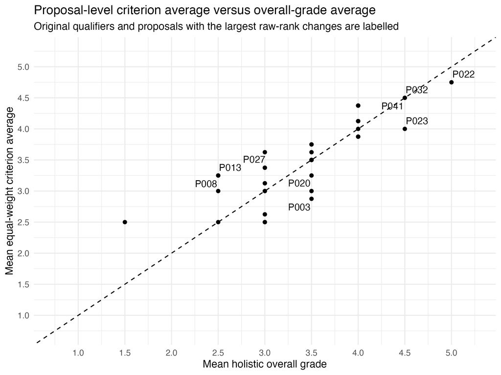

Figure 1: Proposal-level equal-weight criterion average versus mean holistic overall grade. The dashed identity line represents identical proposal-level summaries. All CRS qualifiers are labelled; the five proposals with the largest absolute raw-rank changes are additionally labelled.

The holistic proposal average is relatively coarse because it is calculated from only two integer-valued grades, whereas $A_i$ averages eight criterion scores and therefore has finer numerical resolution. Raw-rank changes are consequently sensitive to the breaking of ties and are not emphasised here.

At the top of the distribution, P022 had a criterion average of 4.75, while P032 and P041 had 4.50. These are three of the four proposals that qualified under the final CRS rule. The fourth qualifier, P023, had a criterion average of 4.00, while several non-qualified proposals had averages of 4.375. Equal weighting therefore preserves substantial agreement with the holistic evaluation but does not reproduce its upper ordering exactly.

# 3 Bayesian ranking framework

## 3.1 Related work

The Bayesian ranking framework used in this project follows Heyard et al. (2022), who developed a hierarchical model for research-proposal evaluation at the Swiss National Science Foundation. Each proposal $i$ is represented by a latent proposal effect $\theta_i$, and uncertainty in the relative ordering of proposals is retained through the posterior distribution of these effects.

Their approach builds on earlier Bayesian methods for ranking random effects. In particular, Laird and Louis (1989) developed Bayes and empirical-Bayes methods for estimating ranks in variance-component models. Heyard et al. summarise posterior ranking uncertainty using the expected rank of each proposal, which is also the principal Bayesian ranking quantity used in this report and is defined formally in Section 3.5.

Bayesian hierarchical models have also been applied directly to grant-review ratings. Johnson (2008) modelled reviewer scoring differences and posterior uncertainty in NIH proposal ratings, while Cao, Stokes and Zhang (2010) developed an ordinal multirater model for ranking grant proposals. The proposal–reviewer structure is closely related to the cross-classified grant-review model of Jayasinghe, Marsh and Bond (2003), in which proposal and reviewer effects are crossed rather than nested.

More recently, Heyard et al. (2025) applied Bayesian expected ranks to individual evaluations of Marie Skłodowska-Curie Actions proposals and compared them with rankings and funding decisions obtained after consensus meetings.

The present analysis therefore does not introduce a new Bayesian ranking method. It takes Heyard et al. as its methodological starting point, reproduces their continuous reference specification as V0, and examines whether a simpler crossed proposal–reviewer model preserves the substantive ranking conclusions in the CRS setting.

## 3.2 V0: Heyard reference model

The reference model V0 reproduces the continuous homogeneous-variance specification of Heyard et al. (2022). Let $r=1,\ldots,84$ index completed reviews, $i=1,\ldots,42$ index proposals, and $j=1,\ldots,9$ index reviewers. For review $r$, let $p(r)$ denote the proposal evaluated and $a(r)$ the reviewer who produced the review. The observed holistic overall grade is $Y_r$, $\bar Y$ denotes its sample mean over all 84 reviews, and $Y=(Y_1,\ldots,Y_{84})^\top$ denotes the full vector of observed grades.

The model is

$$Y_r
\mid
\theta_{p(r)},\lambda_{p(r),a(r)},\sigma
\sim
\mathcal{N}\!\left(
\bar Y+\theta_{p(r)}+\lambda_{p(r),a(r)},
\sigma^2
\right),$$

with proposal effects

$$\theta_i\sim\mathcal{N}(0,\tau_\theta^2),
\qquad i=1,\ldots,42,$$

and assessment effects

$$\lambda_{ij}\sim\mathcal{N}(\nu_j,\tau_\lambda^2),
\qquad
i=1,\ldots,42,\quad j=1,\ldots,9,$$

with

$$\nu_j\sim\mathcal{N}(0,0.5^2),
\qquad j=1,\ldots,9.$$

For review $r$, $\theta_{p(r)}$ is therefore the effect of the proposal being evaluated, $\nu_{a(r)}$ is the persistent scoring tendency of the reviewer who produced that review, and $\lambda_{p(r),a(r)}$ is the corresponding proposal–reviewer assessment effect. Hence

$$\lambda_{p(r),a(r)}-\nu_{a(r)}$$

represents the additional assessment-specific deviation for that observed reviewer–proposal pair.

V0 is retained as the methodological reference model rather than as the preferred CRS specification. Each reviewer–proposal pair is observed only once in the CRS data, so this assessment-specific deviation is informed by only one score and is difficult to distinguish from residual review-level variation. This motivates the simpler V1 model, which retains persistent proposal and reviewer effects but removes the additional assessment-specific layer.

## 3.3 V1: CRS cross-classified model

The CRS-specific V1 model simplifies V0 by removing the proposal–reviewer-specific assessment layer and serves as the main model for the CRS analysis. Using the indexing defined above,

$$Y_r
=
\bar Y
+
\theta_{p(r)}
+
b_{a(r)}
+
\varepsilon_r,
\qquad
\varepsilon_r\sim\mathcal{N}(0,\sigma^2),$$

or equivalently,

$$Y_r
\mid
\theta_{p(r)}, b_{a(r)}, \sigma
\sim
\mathcal{N}\!\left(
\bar Y+\theta_{p(r)}+b_{a(r)},
\sigma^2
\right).$$

Here, $\theta_{p(r)}$ is the effect of the proposal evaluated in review $r$, $b_{a(r)}$ is the persistent scoring tendency of the reviewer who produced that review, and $\varepsilon_r$ captures residual review-level variation. The proposal and reviewer effects satisfy

$$\theta_i\sim\mathcal{N}(0,\tau_\theta^2),
\qquad i=1,\ldots,42,$$

and

$$b_j\sim\mathcal{N}(0,\tau_b^2),
\qquad j=1,\ldots,9.$$
The proposal effects $\theta_i$ are the quantities used for ranking. Because reviewer assignments were based on expertise and availability rather than random allocation, the reviewer effects $b_j$ are interpreted descriptively as reviewer-associated scoring tendencies rather than as causal measures of reviewer bias.

V1 is cross-classified because each grade belongs simultaneously to a proposal and a reviewer, with neither grouping nested within the other. Its hierarchical structure induces partial pooling: proposal effects are shrunk toward zero, which corresponds to the overall mean $\bar Y$ on the observed grade scale, while reviewer effects are pooled analogously. The amount of pooling is determined by the estimated between-proposal and between-reviewer variation, $\tau_\theta^2$ and $\tau_b^2$. This regularisation is particularly relevant because each CRS proposal contributes only two grades.

The likelihood and hierarchical priors are combined through Bayesian updating to obtain the joint posterior distribution of the model parameters. A detailed derivation of this updating and the resulting partial pooling is given in Section 10.2.

## 3.4 Assumptions and prior specification

Both V0 and V1 treat the observed grades as conditionally Gaussian with a common residual variance and assume exchangeable proposal effects around zero. Both models also contain exchangeable zero-centred reviewer-level terms: V0 through $\nu_j$, which centres the proposal–reviewer assessment effects $\lambda_{ij}$, and V1 directly through $b_j$. The overall mean $\bar Y$ is fixed at the observed sample mean rather than estimated as a separate intercept.

For V0,

$$\sigma,\tau_\theta,\tau_\lambda
\sim
\operatorname{Uniform}(0,2),$$

while V1 uses

$$\sigma,\tau_\theta,\tau_b
\sim
\operatorname{Uniform}(0,2).$$

The lower endpoint is implemented numerically as $10^{-6}$. Sensitivity of the main V1 conclusions to the scale priors is examined in Chapter 5.

Although the holistic overall grade is recorded as an integer from 1 to 5, both models retain the continuous Gaussian treatment used in the reference analysis of Heyard et al. (2022). This assumes that adjacent score categories are equally spaced. Because the primary target is the relative ordering of latent proposal effects rather than prediction of valid score categories, this approximation is retained here; its limitations are assessed through posterior predictive checks in Chapter 5.

## 3.5 Posterior ranking quantities

Ranking is based on the posterior distribution of the proposal effects $\theta_1,\ldots,\theta_{42}$ rather than directly on observed score averages. For posterior draw $s$, define the rank of proposal $i$ as

$$R_i^{(s)}
=
1+\sum_{k\neq i}
\mathbb{1}_{\{\theta_k^{(s)}>\theta_i^{(s)}\}},$$

where rank 1 corresponds to the largest proposal effect and $\mathbb{1}_{\{\cdot\}}$ denotes the indicator function.

The posterior mean of this rank distribution is the expected rank,

$$ER_i
=
\operatorname{E}[R_i\mid Y].$$

Equivalently,

$$ER_i
=
1+\sum_{k\neq i}
\mathbb{P}(\theta_k>\theta_i\mid Y),$$

so expected rank is 1 plus the sum of the posterior probabilities that each competing proposal has a larger latent effect than proposal $i$. It is estimated from $S$ posterior draws by

$$ER_i
\approx
\frac{1}{S}\sum_{s=1}^{S}R_i^{(s)}.$$

Expected rank is the principal Bayesian ranking quantity used in this report and follows Heyard et al. (2022). With 42 proposals, the midpoint of the rank scale is 21.5. When pairwise ordering probabilities are close to 0.5, expected ranks therefore move toward the centre of the rank scale.

Three ranking summaries are distinguished throughout the analysis. The **observed-score rank** orders proposals by their mean observed overall grade, with tied observed proposal means receiving average ranks. The **posterior-mean rank** orders the posterior means of $\theta_i$, and the **expected rank** averages the rank of proposal $i$ across the posterior distribution. Rank uncertainty is summarised by the 90% posterior rank interval, defined by the 5th and 95th percentiles of $R_i$.

For particular proposals, pairwise posterior probabilities such as

$$\mathbb{P}(\theta_i>\theta_k\mid Y)$$

provide a direct measure of the evidence that one proposal ranks above another. They are particularly useful when proposals are nearly tied and small model changes alter their integer ranks.

## 3.6 Posterior computation and diagnostics

All Bayesian models were fitted in JAGS from R. V0 used the Heyard reference specification implemented through `ERforResearch`, while V1 used a custom JAGS model with one persistent effect per reviewer.

Unless stated otherwise, each final fit used four Markov chains, 10,000 adaptation iterations, 10,000 burn-in iterations and 50,000 retained iterations per chain, giving 200,000 posterior draws in total. All MCMC fits used the fixed random seed 20260727 for reproducibility.

Posterior-mean ranks, expected ranks, rank intervals and pairwise posterior probabilities were calculated from the retained draws. Computational convergence was assessed using the potential scale reduction factor (PSRF) and effective sample size (ESS). Statistical model adequacy is assessed separately through posterior predictive checks and prior sensitivity in Chapter 5.

# 4 Bayesian ranking results

## 4.1 Main V1 ranking and comparison with the final CRS procedure

Under V1, P022, P032, P023 and P041 occupied posterior-mean ranks 1 to 4, with expected ranks 13.08, 15.87, 15.87 and 16.22, respectively. These are exactly the four proposals that satisfied the final CRS qualification threshold.

Because each observed proposal mean is based on only two integer-valued grades, the deterministic observed-score ranking is itself highly clustered. Across the 42 proposals, only seven distinct mean overall grades occur, so many proposals share exactly the same observed-score rank. The clusters in the left-hand column of Figure 2 therefore arise before any Bayesian modelling is applied.

V1 produces a finer posterior-mean ordering by accounting for the crossed proposal–reviewer structure and partial pooling. However, the posterior rank distributions show that many of these finer distinctions are only weakly supported by the available reviews. The 90% posterior rank interval for P022 was 1–36; for P023 and P032 it was 1–37; and for P041 it was 1–38. Expected rank summarises this uncertainty rather than implying that the deterministic score averages provide a more precisely identified underlying ordering. The observed-score rank, posterior-mean rank and expected rank are compared in Figure 2.

The Bayesian analysis therefore does not change the group of four proposals identified by the CRS procedure, but adds information about how uncertain their relative latent positions remain. The CRS rule determines qualification from the observed grades, whereas V1 quantifies uncertainty in the underlying proposal ordering. It is therefore interpreted as uncertainty-aware decision support rather than as a retrospective replacement for the qualification rule.

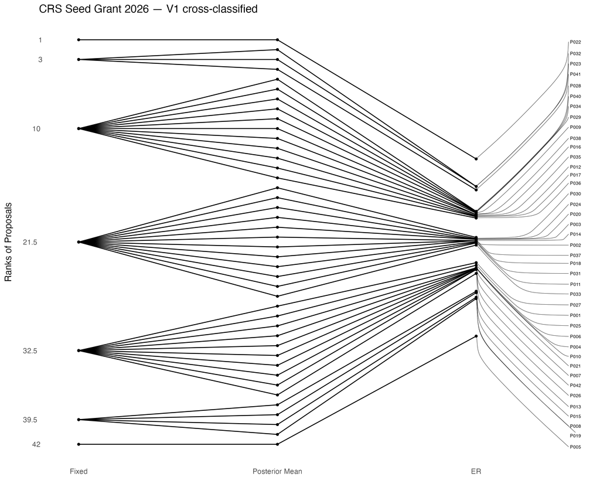

Figure 2: Proposal rankings under the observed-score ranking, posterior-mean ranking and posterior expected rank for the V1 cross-classified model. The movement of expected ranks toward the centre of the rank scale reflects substantial posterior uncertainty in the exact proposal ordering. The package-generated labels “Fixed” and “ER” correspond to the observed-score rank and posterior expected rank, respectively.

## 4.2 Robustness of the ranking to the Heyard reference specification

The V0 Heyard reference model produced almost the same ranking as V1. The four CRS qualifiers again occupied the first four posterior-mean positions. Across all 42 proposals, the Spearman correlation between posterior-mean ranks was 0.9951 and the Pearson correlation between expected ranks was 0.9916. The agreement is shown in Figure 3.

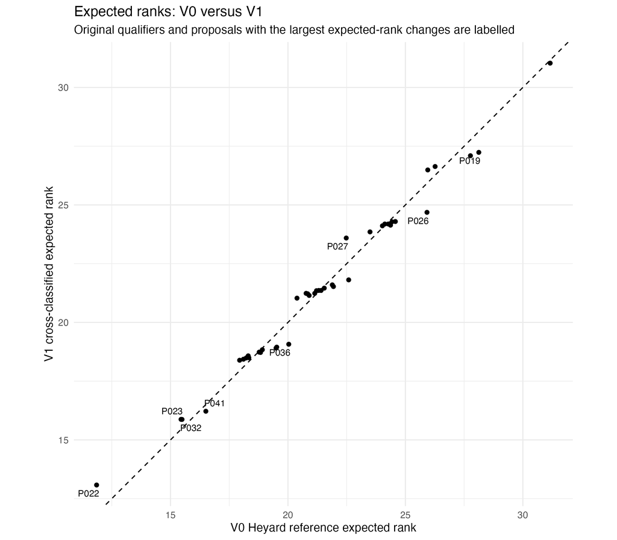

Figure 3: Posterior expected ranks under the V0 Heyard reference model and the V1 cross-classified model. The dashed identity line represents identical expected ranks under both models.

Small changes in integer ranks nevertheless occurred for proposals that were almost indistinguishable. Twenty-six of the 42 proposals changed posterior-mean rank between V0 and V1, but the mean absolute change was only 0.86 positions and the maximum was three. For example, V0 places P023 above P032, while V1 reverses them. Yet

$$\mathbb{P}(\theta_{032}>\theta_{023}\mid Y)=0.498955$$

under V0 and

$$\mathbb{P}(\theta_{032}>\theta_{023}\mid Y)=0.500470$$

under V1. The apparent reversal therefore reflects an almost exact posterior tie rather than meaningful disagreement between the models.

Rank uncertainty was similarly stable. The mean width of the 90% posterior rank intervals was 36.50 positions under V0 and 36.74 under V1, with median width 37 under both models. Thus, simplifying V0 to V1 changes little about either the broad ordering or the conclusion that exact ranks are poorly identified. Detailed V0 results and computational diagnostics are provided in Section 10.3.

## 4.3 Bayesian ranking using the equal-weight criterion average

The descriptive analyses in Section 2.3 and Section 2.4 show that the holistic grade and equal-weight criterion average contain overlapping but not identical information. To examine whether this difference persists after accounting for reviewer-associated scoring tendencies and ranking uncertainty, V1 was fitted again using the review-level criterion average $A_r$ as the outcome:

$$A_r
\sim
\mathcal{N}\!\left(
\bar{A}
+
\theta^{(A)}_{p(r)}
+
b^{(A)}_{a(r)},
\sigma_A^2
\right),$$

with

$$\theta_i^{(A)}\sim\mathcal{N}(0,\tau_{\theta,A}^2),
\qquad
b_j^{(A)}\sim\mathcal{N}(0,\tau_{b,A}^2),$$
where $\bar A$ denotes the observed mean of the 84 review-level criterion averages.

The reviewer–proposal assignments, priors and MCMC settings were identical to the overall-grade V1 fit; only the outcome and its observed mean changed. The fit showed satisfactory computational diagnostics (maximum PSRF 1.0032; minimum ESS 1,863).

Changing the evaluation outcome had a noticeably larger effect on the ranking than changing from V0 to V1. The Spearman correlation between posterior-mean ranks from the two V1 fits was 0.873, while the Pearson correlation between expected ranks was 0.863. The mean absolute expected-rank change was 2.97 positions and the maximum was 7.89. By comparison, the correlation between V0 and V1 expected ranks for the same holistic outcome was 0.9916. The comparison is shown in Figure 4.

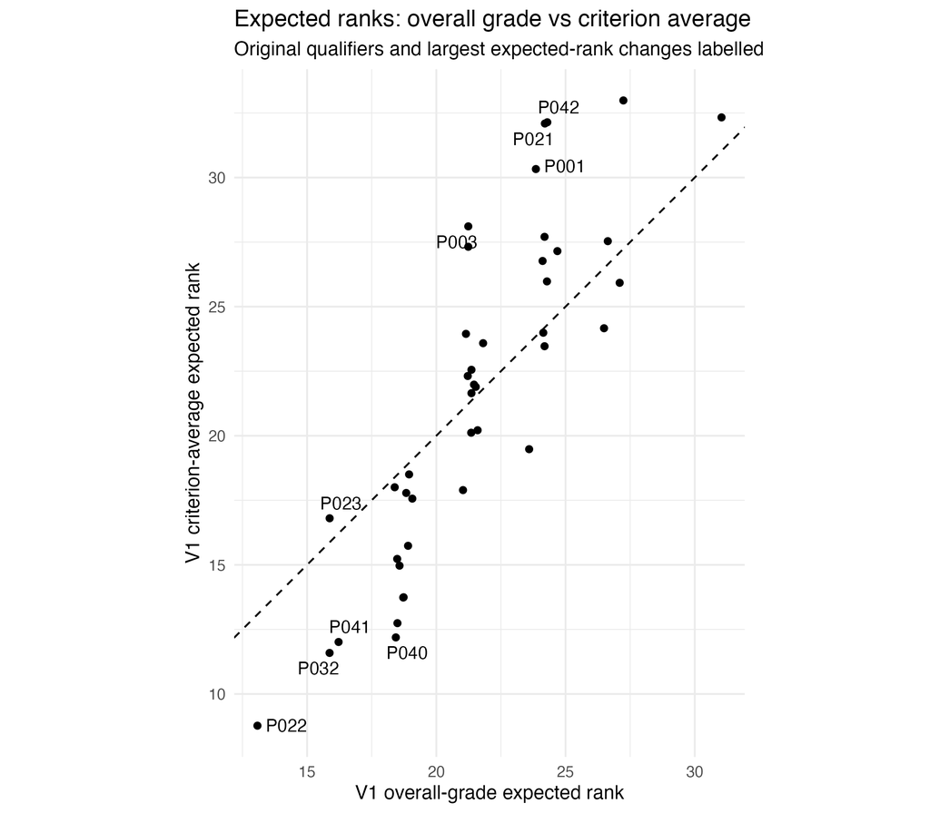

Figure 4: Posterior expected ranks from V1 fitted to the holistic overall grade and to the equal-weight criterion average. The dashed identity line represents identical expected ranks under both outcome definitions. CRS qualifiers and proposals with the largest expected-rank changes are labelled.

The upper ordering also changed. P022 and P032 remained at posterior-mean ranks 1 and 2, P041 moved from rank 4 to rank 3, and P040 moved from rank 6 to rank 4. P023 showed the largest change among these proposals, moving from posterior-mean rank 3 to rank 11. That change appears less substantial when posterior uncertainty is considered: P023’s expected rank changed only from 15.87 to 16.80, whereas P040 improved from 18.43 to 12.19. This illustrates why changes in exact integer ranks should be interpreted together with the posterior rank uncertainty.

The criterion-average fit produced somewhat narrower posterior rank distributions: the mean width of the 90% posterior rank intervals decreased from 36.74 to 33.19 positions and the median from 37 to 34. The criterion average also had lower observed dispersion than the holistic grade (standard deviations 0.772 and 0.950, respectively). Because the criterion average itself combines four scores, part of this reduction in variation may arise mechanically from averaging. The corresponding variance decomposition is examined in Section 5.2.

These results do not establish that either outcome is preferable. They show that the definition of the evaluation outcome has a larger effect on the posterior ordering than the change from V0 to V1 while holding the holistic outcome fixed.

# 5 Validation and sensitivity analysis of V1

## 5.1 Validation strategy

Unless stated otherwise, this chapter evaluates V1 fitted to the holistic overall grade, the main working model. The close agreement between V0 and V1 shows that the ranking is not sensitive to the additional assessment-specific layer in V0, but does not establish that V1 adequately represents the observed reviews.

Validation therefore addresses three questions: whether posterior computation is stable, whether V1 reproduces important features of the observed grades, and whether the main conclusions depend materially on the baseline scale priors.

## 5.2 Computational and variance diagnostics

The V1 posterior was sampled reliably. Across all monitored parameters, the maximum PSRF was 1.0017 and the minimum effective sample size was 1,627. The corresponding trace plots are provided in Section 10.4.

Under V1, the marginal variance of an individual grade is

$$\operatorname{Var}(Y_r)
=
\tau_\theta^2+\tau_b^2+\sigma^2.$$

For posterior draw $s$, let the total marginal variance be

$$V_{\mathrm{tot}}^{(s)}
=
\left(\tau_\theta^{(s)}\right)^2
+
\left(\tau_b^{(s)}\right)^2
+
\left(\sigma^{(s)}\right)^2.$$

The corresponding variance shares are

$$\rho_{\mathrm{proposal}}^{(s)}
=
\frac{\left(\tau_\theta^{(s)}\right)^2}{V_{\mathrm{tot}}^{(s)}},
\qquad
\rho_{\mathrm{reviewer}}^{(s)}
=
\frac{\left(\tau_b^{(s)}\right)^2}{V_{\mathrm{tot}}^{(s)}},
\qquad
\rho_{\mathrm{residual}}^{(s)}
=
\frac{\left(\sigma^{(s)}\right)^2}{V_{\mathrm{tot}}^{(s)}}.$$

For the overall-grade model, their posterior medians were 0.050, 0.026 and 0.896, with corresponding 95% credible intervals of approximately $[0.0002,0.289]$, $[0.0001,0.240]$ and $[0.615,0.995]$.

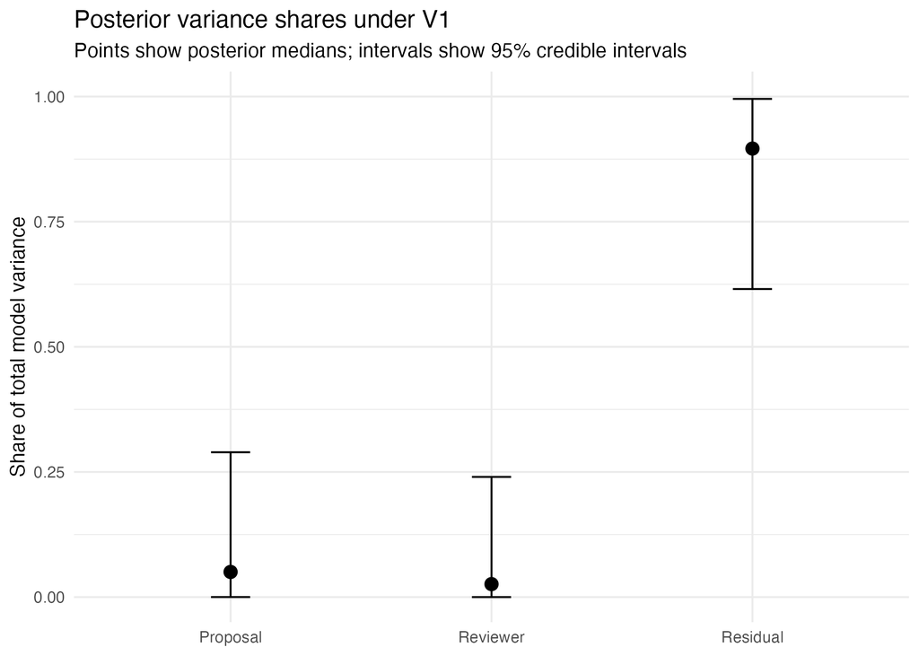

Figure 5: Posterior variance shares under V1. Points show posterior medians and vertical intervals show 95% credible intervals.

The proposal variance share also has a reliability interpretation. For two ratings of the same proposal by different reviewers $j$ and $k$, both ratings share the same proposal effect $\theta_i$. Under the model’s independence assumptions, this gives

$$\operatorname{Cov}(Y_{ij},Y_{ik})
=
\tau_\theta^2,$$

while each rating has marginal variance $\tau_\theta^2+\tau_b^2+\sigma^2$. Therefore,

$$\operatorname{Cor}(Y_{ij},Y_{ik})
=
\frac{\tau_\theta^2}
{\tau_\theta^2+\tau_b^2+\sigma^2}
=
\rho_{\mathrm{proposal}}.$$

Thus, under V1, the proposal variance share is also the model-implied correlation between two ratings of the same proposal by different reviewers, corresponding to the cross-classified reliability interpretation of Jayasinghe et al. (2003). Its posterior median of approximately 0.05 indicates weak agreement attributable to a shared proposal effect. Most fitted variation is instead associated with residual review-level variation, helping to explain the broad posterior ranks despite two ratings per proposal. This decomposition alone does not, however, establish that the sparse assignment design causes the ranking uncertainty.

For comparison, the same decomposition was calculated for V1 fitted to the equal-weight criterion average.

Table 2: Posterior median variance shares under V1 for the holistic overall grade and equal-weight criterion-average outcomes.

| Response | Proposal share | Reviewer share | Residual share |
| --- | --- | --- | --- |
| Holistic overall grade | 0.050 | 0.026 | 0.896 |
| Equal-weight criterion average | 0.192 | 0.046 | 0.733 |

The shares sum to one within each posterior draw. Because the table reports the median of each share separately, the displayed medians need not sum exactly to one.

The criterion-average fit attributes a larger share of variation to proposals and a smaller share to residual variation. However, the two decompositions refer to different outcomes: $A_r$ averages four scores and has lower observed dispersion than the holistic grade. The larger proposal share therefore does not establish that the criterion average is a better evaluation measure.

## 5.3 Posterior predictive assessment

Posterior predictive checks used 5,000 replicated datasets to assess whether V1 reproduces the observed location, dispersion and reviewer disagreement. For posterior draw $s$ and review $r$, let $Y_r^{\mathrm{rep},(s)}$ denote the replicated grade,

$$Y_r^{\mathrm{rep},(s)}
\sim
\mathcal{N}\!\left(
\bar Y
+
\theta_{p(r)}^{(s)}
+
b_{a(r)}^{(s)},
\left(\sigma^{(s)}\right)^2
\right).$$

The observed mean absolute disagreement between the two reviews of a proposal was 1.095, compared with a posterior predictive mean of 1.064. Approximately 40% of replicated datasets produced at least as much mean disagreement as observed, so the observed value is not unusual under V1.

A more detailed check showed that this close correspondence is not mechanically induced by the shared proposal effect, which cancels when the two reviews of a proposal are differenced. The resulting analytic expected disagreement was 1.066, close to the simulated value 1.064, and most model-implied disagreement arises from residual review-level variation rather than persistent reviewer effects. Mapping replicated grades to the observed integer-valued 1–5 grid did not improve agreement for mean absolute disagreement, but substantially reduced the apparent discrepancy in the proportion of proposals with disagreement of at least two score points: the corresponding posterior predictive probability increased from 0.0088 to 0.272. Full derivations and diagnostics are given in Section 10.5.

The Gaussian likelihood also permits grades outside the admissible range: on average, 6.6% of replicated grades were below 1 or above 5. V1 is therefore retained as a continuous approximation for ranking latent proposal effects, rather than as a literal generative model for valid future score categories.

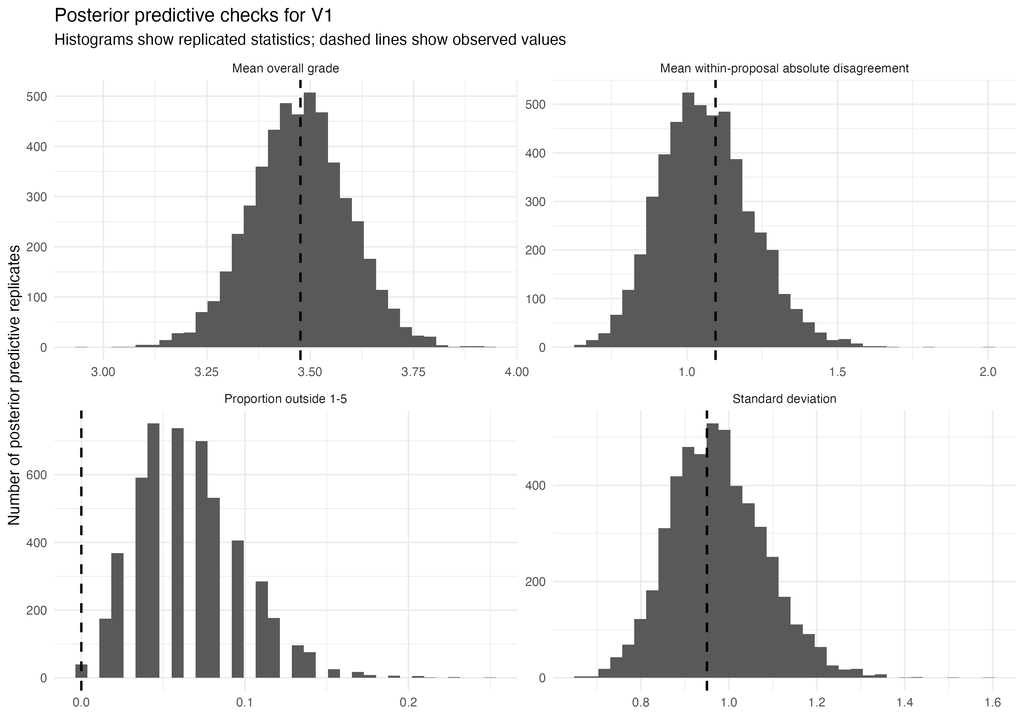

Figure 6: Posterior predictive checks for V1. Histograms show statistics calculated from replicated datasets, while dashed vertical lines show the corresponding observed values.

## 5.4 Prior sensitivity

The baseline scale priors

$$\sigma,\tau_\theta,\tau_b\sim\operatorname{Uniform}(0,2)$$

were replaced by independent $\operatorname{HalfNormal}(0,1)$ priors. This follows the suggestion of Heyard et al. (2022) that half-normal priors provide a useful alternative specification for variance parameters. The $\operatorname{HalfNormal}(0,1)$ distribution is positive and unbounded, places more prior mass near small scale values, and still allows values above 2. It therefore provides a meaningfully different prior shape for the sensitivity analysis.

The ranking was essentially unchanged. The Pearson correlation between expected ranks under the two prior specifications was 0.99994, the mean absolute expected-rank change was 0.093 positions, and the maximum was 0.283. The median width of the 90% posterior rank intervals remained 37 under both specifications. Additional parameter and ranking summaries are provided in Section 10.7.

## 5.5 Validation conclusion

V1 showed stable posterior computation, reproduced the observed mean, dispersion and mean reviewer disagreement reasonably well, and was insensitive to the alternative scale priors tested here. Most fitted variation was associated with residual review-level variation, while exact proposal ranks remained weakly identified. The principal model-form limitation is the continuous Gaussian treatment of the five-point score, which permits replicated values outside the admissible range. Subject to this approximation and the non-random reviewer assignment, V1 is retained as the working model for the review-design analysis.

# 6 Graph-based review design

## 6.1 Motivation and scope

The preceding analysis shows substantial uncertainty in the exact latent proposal ranking. Because each proposal received only two reviews, the reviewer–proposal assignment structure determines which proposal and reviewer effects are jointly informed by the observed grades.

Reviewer allocation can itself be viewed as a statistical-design problem. Cook et al. (2005) study proposal allocation with the aim of facilitating ranking, while Stelmakh, Shah and Singh (2021) consider fairness and statistical accuracy in peer-review assignment. Osting, Brune and Osher (2014) study targeted additions to an existing ranking graph, and Simpson and Roberts (2015) provide a Bayesian example of selecting informative agent–task assignments. These settings differ from CRS, but motivate treating additional reviews as an information-design problem.

The present analysis does not assess whether the original CRS assignments were appropriate. They were based on expertise and availability, while detailed eligibility and conflict-of-interest information is unavailable. Instead, the observed assignment structure is used to ask which hypothetical additional reviews would reduce posterior uncertainty under V1. The calculation evaluates the information gained from adding an assignment itself; it does not simulate a specific numerical grade for that hypothetical review and then refit the complete Bayesian model.

The analysis first compares individual additional assignments using established A-, D- and E-optimality criteria. The primary A-optimality criterion is then extended to small review budgets to compare random, disagreement-targeted and sequential model-based allocation.

## 6.2 Reviewer–proposal assignment structure

The CRS assignment structure can be represented as a bipartite graph: its vertices form two groups, proposals and reviewers, and every edge joins a proposal to a reviewer.

This is analogous to the Levi, or incidence, graph of an incomplete block design (Bailey and Cameron 2011). Proposals play the role of treatments and reviewers the role of blocks, with an edge indicating that a reviewer evaluated a proposal.

Formally,

$$G=(P\cup R,E),
\qquad
P=\{P_1,\ldots,P_{42}\},
\qquad
R=\{R_1,\ldots,R_9\},$$

with $(P_i,R_j)\in E$ whenever reviewer $j$ evaluated proposal $i$. Hence,

$$|P|=42,\qquad |R|=9,\qquad |E|=84.$$

The degree of a vertex is its number of incident edges. Every proposal has degree two, while reviewer degrees equal their workloads and range from 6 to 12.

A subset of the observed graph is shown in Figure 7 to illustrate the bipartite structure.

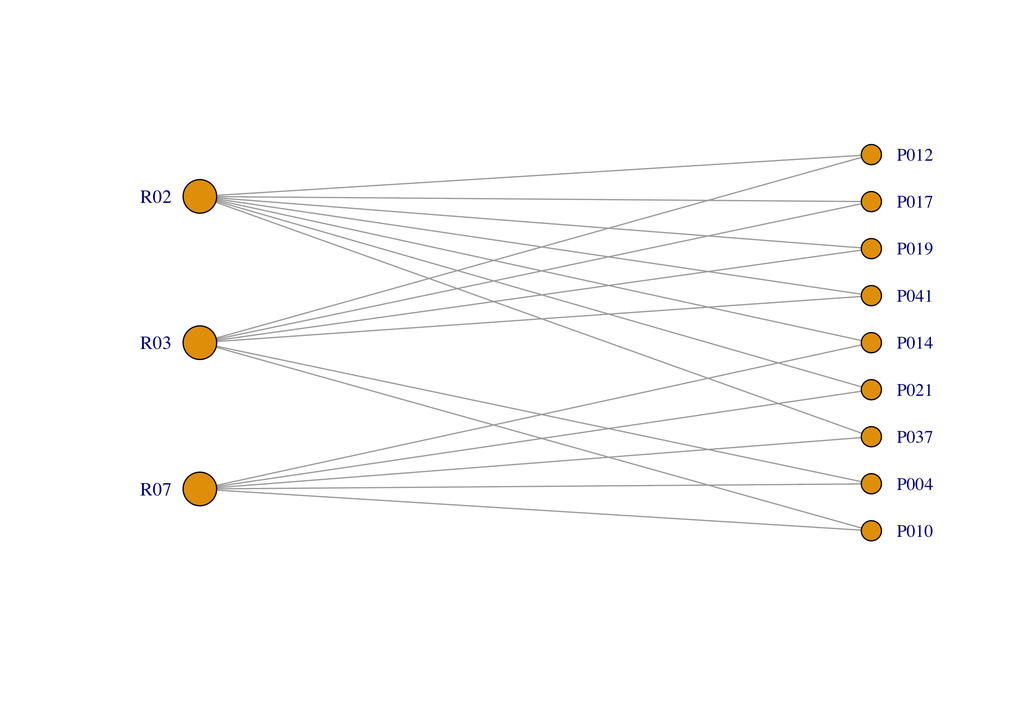

Figure 7: Illustrative subset of the CRS reviewer–proposal assignment graph. Reviewer vertices are shown on the left and proposal vertices on the right; each edge represents one completed review.

The graph records only which reviews occurred, not the grades assigned. It therefore represents the design of the evaluation separately from its observed outcomes.

## 6.3 Statistical relevance of the assignment structure

The graph is statistically relevant because incidence matrices and graph Laplacians arise directly in the information matrices of incomplete block designs. Bailey and Cameron (2011) show this connection for an additive treatment–block model. V1 has an analogous crossed structure, with proposal effects replacing treatment effects and reviewer effects replacing block effects.

To obtain the standard signed incidence representation, define

$$c_j=-b_j.$$

Here, $c_j$ is only a sign-transformed reviewer effect; it does not denote a graph connection.

For the graph representation, it is convenient to index an observed grade by the endpoints of its edge. Write $Y_{ij}$ and $\varepsilon_{ij}$ for the grade and residual associated with an observed reviewer–proposal pair $(i,j)\in E$. The V1 model for an observed edge can then be written as

$$Y_{ij}-\bar Y
=
\theta_i-c_j+\varepsilon_{ij},
\qquad
\varepsilon_{ij}\sim\mathcal N(0,\sigma^2).$$

Collect the effects into

$$\beta
=
(\theta_1,\ldots,\theta_{42},c_1,\ldots,c_9)^\top.$$

For edge $e=(i,j)$, let $x_e$ be the oriented incidence vector with $+1$ at proposal $i$, $-1$ at reviewer $j$, and zero elsewhere. Stacking the 84 incidence vectors as rows gives the incidence matrix $X$.

Let $Y\in\mathbb R^{84}$ denote the vector obtained by stacking the 84 observed grades $Y_{ij}$ in the same order as the rows of $X$, and let $\varepsilon\in\mathbb R^{84}$ denote the corresponding vector of residual terms $\varepsilon_{ij}$, stacked in the same order. Under the model assumptions,

$$\varepsilon\sim\mathcal N(0,\sigma^2I_{84}).$$

Let $\mathbf 1\in\mathbb R^{84}$ denote the vector of ones. Then

$$Y-\bar Y\mathbf 1
=
X\beta+\varepsilon.$$

For an oriented incidence matrix,

$$X^\top X=L_G,$$

where $L_G$ is the graph Laplacian: diagonal entries are vertex degrees and off-diagonal entries are $-1$ for connected proposal–reviewer pairs and zero otherwise.

Here, precision means the inverse of covariance. Since the proposal and reviewer priors have variances $\tau_\theta^2$ and $\tau_b^2$, their corresponding prior precisions are $\tau_\theta^{-2}$ and $\tau_b^{-2}$.

Conditional on $\tau_\theta$ and $\tau_b$, the prior precision matrix for $\beta$ is

$$P_0
=
\begin{pmatrix}
\tau_\theta^{-2}I_{42} & 0_{42\times9}\\
0_{9\times42} & \tau_b^{-2}I_9
\end{pmatrix}.$$

The zero off-diagonal blocks reflect prior independence between the proposal and reviewer effects.

Conditional on $\sigma$, $\tau_\theta$ and $\tau_b$, the posterior precision and covariance matrices are

$$Q
=
P_0+\frac{1}{\sigma^2}L_G,
\qquad
V=Q^{-1}.$$

The assignment graph thus enters directly into posterior precision: changing an edge changes $L_G$ and therefore the conditional posterior covariance.

The review-design calculation therefore follows a simple sequence: the assignment graph determines $L_G$, $L_G$ enters the conditional posterior precision $Q$, $Q^{-1}$ determines posterior covariance, and additional reviews are evaluated by how much they reduce uncertainty in the proposal-effect block of that covariance.

A full derivation is given in Section 10.8.

## 6.4 Quantifying uncertainty for review design

The statistical value of an additional review depends on how uncertainty is defined. Rather than introducing a CRS-specific measure, the analysis uses A-, D- and E-optimality, established criteria in experimental design (Bailey and Cameron 2011; Osting et al. 2014).

Because the Bayesian ranking is based on the 42 proposal effects rather than the reviewer effects, the relevant uncertainty is the posterior uncertainty in

$$\theta
=
(\theta_1,\ldots,\theta_{42})^\top.$$

Conditional on $\sigma$, $\tau_\theta$ and $\tau_b$, partition the full $51\times51$ posterior covariance matrix as

$$V
=
\begin{pmatrix}
V_\theta & V_{\theta c}\\
V_{c\theta} & V_c
\end{pmatrix}.$$

The matrix $V_\theta\in\mathbb R^{42\times42}$ is therefore the conditional posterior covariance matrix of the proposal effects,

$$V_\theta
=
\operatorname{Cov}
\left(
\theta
\mid
Y,\sigma,\tau_\theta,\tau_b
\right).$$

Its diagonal entries are the conditional posterior variances of individual proposal effects, while its off-diagonal entries are their conditional posterior covariances.

### 6.4.1 A-optimality: average uncertainty in pairwise proposal comparisons

Ranking depends on comparisons between proposal effects. For proposals $i$ and $k$, the conditional posterior variance of their difference is

$$\operatorname{Var}
\left(
\theta_i-\theta_k
\mid
Y,\sigma,\tau_\theta,\tau_b
\right)
=
(e_i-e_k)^\top V_\theta(e_i-e_k),$$

where $e_i$ denotes the $i$th standard basis vector in $\mathbb R^{42}$.

There are

$$\binom{42}{2}
=
\frac{42\cdot41}{2}
=
861$$

unordered proposal pairs. The A-optimality loss is defined as the average posterior variance across these 861 pairwise contrasts,

$$L_A(V_\theta)
=
\frac{1}{861}
\sum_{i<k}
(e_i-e_k)^\top V_\theta(e_i-e_k).$$

Thus, smaller values of $L_A$ indicate greater average precision in pairwise proposal comparisons. A-optimality is treated as the **primary criterion** because the substantive target is the relative ordering of proposals. Its loss is the average posterior variance across all pairwise proposal contrasts, which are the quantities that directly determine pairwise ordering. It therefore provides a symmetric global measure of ranking precision without privileging a particular proposal or contrast direction.

### 6.4.2 Proposal contrasts and the centering matrix

The absolute level of all proposal effects is irrelevant for ranking. Adding the same constant $d$ to every proposal effect,

$$\theta
\longmapsto
\theta+d\mathbf 1,$$

does not change any pairwise difference $\theta_i-\theta_k$. Ranking therefore depends only on contrasts between proposal effects.

To remove this common-shift direction, define the centering matrix

$$H
=
I_{42}
-
\frac{1}{42}\mathbf 1\mathbf 1^\top,$$

where $\mathbf 1\in\mathbb R^{42}$ is the vector of ones. For any $x\in\mathbb R^{42}$,

$$Hx
=
x-\bar x\mathbf 1,$$

so $H$ subtracts the mean of the components of $x$. In particular,

$$H\mathbf 1=0.$$

Multiplication by $H$ removes the common component of a vector. In particular, for any $a\in\mathbb R^{42}$,

$$Ha
=
a-\bar a\mathbf 1,
\qquad
\bar a=\frac{1}{42}\mathbf 1^\top a.$$

Thus, $Ha$ has entries summing to zero. Moreover, if $a$ already satisfies $\mathbf 1^\top a=0$, then $Ha=a$, whereas $H\mathbf 1=0$. The matrix $H$ therefore removes the common-shift direction and projects onto the 41-dimensional proposal-contrast subspace

$$\{a\in\mathbb R^{42}:\mathbf 1^\top a=0\}.$$

This is the space of linear comparisons between proposal effects whose coefficients sum to zero. Pairwise differences are a special case because $e_i-e_k$ belongs to this subspace.

The covariance of the centred proposal-effect vector $H\theta$ is

$$\operatorname{Cov}
\left(
H\theta
\mid
Y,\sigma,\tau_\theta,\tau_b
\right)
=
HV_\theta H,$$

since $H$ is symmetric. Thus, $HV_\theta H$ describes posterior uncertainty after removing the common-shift direction that is irrelevant for ranking.

This projection is used because ranking is invariant to a common shift of all proposal effects, not because $V_\theta$ itself is singular.

Because one of the 42 directions has been removed, $HV_\theta H$ has one zero eigenvalue corresponding to $\mathbf 1$ and 41 non-zero eigenvalues,

$$\lambda_1,\ldots,\lambda_{41}.$$

### 6.4.3 D-optimality: joint uncertainty in the contrast space

D-optimality summarises the overall joint uncertainty in the 41-dimensional proposal-contrast space. Its loss is

$$L_D(V_\theta)
=
\sum_{\ell=1}^{41}\log(\lambda_\ell)
=
\log\operatorname{pdet}(HV_\theta H),$$

where $\operatorname{pdet}$ denotes the product of the non-zero eigenvalues.

The square roots of the eigenvalues determine, up to a common scaling factor, the lengths of the principal semi-axes of the posterior uncertainty ellipsoid in the contrast space. Its volume is therefore proportional to

$$\prod_{\ell=1}^{41}\sqrt{\lambda_\ell}.$$

Minimising $L_D$ is consequently equivalent to minimising this joint uncertainty volume.

### 6.4.4 E-optimality: worst-case contrast uncertainty

The 41 non-zero eigenvalues of $HV_\theta H$ describe posterior uncertainty along orthogonal directions in the proposal-contrast space. E-optimality focuses only on the largest of these eigenvalues, corresponding to the least precisely determined contrast direction:

$$L_E(V_\theta)
=
\lambda_{\max}(HV_\theta H).$$

Equivalently,

$$L_E(V_\theta)
=
\max_{\substack{
\mathbf 1^\top a=0\\
\|a\|=1
}}
a^\top V_\theta a.$$

Here, $a^\top\theta$ represents a linear comparison of proposal effects. The condition $\mathbf 1^\top a=0$ makes it a contrast, so that adding the same constant to every proposal effect does not change the comparison. The normalisation $\|a\|=1$ prevents the variance from being made arbitrarily large simply by rescaling $a$. Since

$$\operatorname{Var}(a^\top\theta\mid Y,\sigma,\tau_\theta,\tau_b)
=
a^\top V_\theta a,$$

the equivalent maximum formulation asks for the unit-length proposal contrast with the largest conditional posterior variance. E-optimality therefore targets the worst-determined direction in the contrast space.

The three criteria consequently emphasise different aspects of uncertainty: A-optimality averages uncertainty over all pairwise proposal comparisons, D-optimality summarises overall joint uncertainty in the contrast space, and E-optimality targets the single least precisely estimated normalised contrast direction. D- and E-optimality are retained as sensitivity criteria, while A-optimality is our primary criterion.

## 6.5 Statistical value of a single additional review

There are

$$42\times9-84=294$$

currently unobserved reviewer–proposal pairs. Because expertise, eligibility and conflict-of-interest information is unavailable, all 294 are treated as hypothetical candidates; their rankings describe statistical informativeness under V1 rather than operational assignment recommendations.

The calculation propagates uncertainty in the scale parameters by evaluating each candidate over 5,000 approximately evenly spaced posterior draws from V1.

For posterior draw $s$, let

$$P_0^{(s)}
=
\begin{pmatrix}
\left(\tau_\theta^{(s)}\right)^{-2}I_{42}
&
0_{42\times9}
\\
0_{9\times42}
&
\left(\tau_b^{(s)}\right)^{-2}I_9
\end{pmatrix}$$

denote the prior precision matrix evaluated at that draw. Define

$$Q^{(s)}
=
P_0^{(s)}
+
\frac{1}{\left(\sigma^{(s)}\right)^2}L_G,
\qquad
V^{(s)}
=
\left(Q^{(s)}\right)^{-1}.$$

For a candidate edge $e$ with incidence vector $x_e$, adding the review changes the graph Laplacian by

$$L_{G+e}
=
L_G+x_ex_e^\top.$$

The corresponding updated precision matrix for posterior draw $s$ is therefore

$$Q_e^{(s)}
=
Q^{(s)}
+
\frac{1}{\left(\sigma^{(s)}\right)^2}
x_ex_e^\top.$$

The updated covariance is

$$V_e^{(s)}
=
\left(Q_e^{(s)}\right)^{-1}.$$

This covariance could be obtained by inverting the full updated precision matrix for every candidate edge. Because the change in precision is rank one, the Sherman–Morrison identity instead gives the updated inverse directly:

$$V_e^{(s)}
=
V^{(s)}
-
\frac{
V^{(s)}x_ex_e^\top V^{(s)}
}{
\left(\sigma^{(s)}\right)^2
+
x_e^\top V^{(s)}x_e
}.$$

Thus, $V_e^{(s)}$ is the conditional posterior covariance that would result from adding candidate review $e$ while holding the scale parameters fixed at posterior draw $s$.

Let $V_\theta^{(s)}$ and $V_{\theta,e}^{(s)}$ denote the $42\times42$ proposal-effect blocks of $V^{(s)}$ and $V_e^{(s)}$, respectively. These matrices describe the conditional posterior uncertainty in the proposal effects before and after adding candidate review $e$.

Conditional on the scale parameters, the covariance reduction depends on the assignment added, not on the future numerical grade. The actual grade would affect the posterior mean of the proposal and reviewer effects, but not this conditional covariance update.

For criterion $C\in\{A,D,E\}$, define the reduction in uncertainty for posterior draw $s$ as

$$\Delta_C^{(s)}(e)
=
L_C\!\left(V_\theta^{(s)}\right)
-
L_C\!\left(V_{\theta,e}^{(s)}\right).$$

The posterior-averaged utility of candidate edge $e$ is then

$$\Delta_C(e)
=
\frac{1}{S}
\sum_{s=1}^{S}
\Delta_C^{(s)}(e),
\qquad
S=5000.$$

Larger values of $\Delta_C(e)$ indicate a greater posterior-averaged reduction in uncertainty under criterion $C$.

A 1,000-draw calculation gave materially similar highest-ranked assignments, supporting the use of 5,000 draws in the final analysis.

As a further sensitivity check, posterior-median plug-in scale parameters produced broadly similar candidate rankings and retained the same leading A-optimal assignments. Detailed results are given in Section 10.9.

This is not a full prospective refit of V1. Within each posterior draw, the scale parameters remain fixed; an actually observed additional grade could also update their posterior distributions.

## 6.6 Comparison of single-review criteria

The posterior-averaged calculation identified a small group of assignments with almost identical A-optimality utility. P026–R02 gave the largest reduction in the A-optimality loss,

$$\Delta_A(\text{P026--R02})
=
3.0535\times10^{-4}.$$

It was followed by P005–R02 and P015–R02 at $3.0534\times10^{-4}$. These differences are too small to support a meaningful distinction between the three assignments.

D-optimality produced a similar upper ordering, whereas E-optimality differed more substantially. Across all 294 candidate assignments, the Spearman rank correlations between the criterion-specific candidate rankings were

$$\rho_{\mathrm S}(A,D)=0.926,
\qquad
\rho_{\mathrm S}(A,E)=0.234,
\qquad
\rho_{\mathrm S}(D,E)=0.040.$$

Thus, A- and D-optimality agree strongly about which additional assignments are most informative, while E-optimality, which targets the worst remaining contrast direction, produces a substantially different ordering. The strong agreement between A and D suggests that the A-optimal ranking is robust across two global measures of proposal uncertainty. Its disagreement with E shows, however, that the preferred assignment is not criterion-independent: a design focused specifically on the single worst-identified contrast can favour different reviewer–proposal pairs.

Table 3: Selected highest-ranked candidate assignments under the posterior-averaged A-, D- and E-optimality criteria.

| Candidate assignment | A rank | D rank | E rank |
| --- | --- | --- | --- |
| P026–R02 | 1 | 1 | 18 |
| P005–R02 | 2 | 3 | 1 |
| P015–R02 | 3 | 2 | 2 |
| P032–R02 | 4 | 4 | 5 |
| P029–R02 | 4 | 5 | 6 |
| P034–R02 | 4 | 5 | 7 |
| P005–R03 | 8 | 41 | 3 |
| P015–R03 | 9 | 42 | 4 |

The full A-optimality pattern is shown in Figure 8. High utilities are concentrated among assignments involving R02. This reflects R02’s position in the existing assignment graph and the resulting posterior covariance structure under V1; it should not be interpreted as evidence that R02 is intrinsically a better, worse, more reliable, or more informative reviewer.

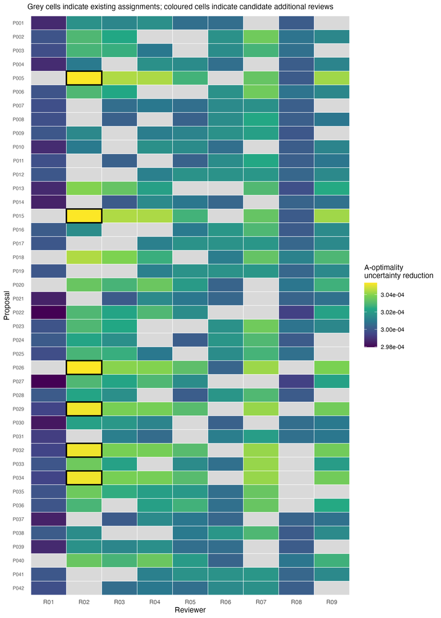

Figure 8: Posterior-averaged A-optimality utility for hypothetical additional reviewer–proposal assignments. Grey cells indicate existing assignments; outlined cells form the highest-ranked A-optimality group. Larger values indicate greater reductions in average pairwise proposal-contrast variance.

Targeting proposals with high observed reviewer disagreement addresses a different objective. It prioritises proposals whose original reviewers gave divergent judgments, whereas A-optimality reduces global posterior contrast uncertainty. This motivates the disagreement-targeted benchmark considered next.

## 6.7 Practical comparison of limited-review allocation policies

The single-review calculation was extended to budgets of one to six additional reviews. Each proposal could receive at most one additional review, so the policies allocate selective third reviews.

Three allocation policies were compared.

The **random policy** selects an available reviewer–proposal assignment uniformly at random.

The **disagreement-targeted policy** first identifies, among proposals that have not yet received an additional review, those with the largest absolute difference between their two original grades. Within that set, it chooses the available reviewer assignment with the largest posterior-averaged A-optimality reduction defined in Section 6.5.

The **sequential A-optimal policy** uses a greedy sequential procedure: at each step, it selects the currently best remaining assignment according to A-optimality, updates the covariance, and then selects the next assignment. It therefore does not search over all possible sets of additional reviews simultaneously and is not guaranteed to identify the jointly optimal set for a given review budget.

For posterior draw $s$, let $V_{\theta,0}^{(s)}$ denote the proposal-effect covariance matrix before any additional reviews are added. For policy $\pi$ and budget $m$, let $V_{\theta,m,\pi}^{(s)}$ denote the corresponding proposal-effect covariance after allocating $m$ additional reviews according to that policy.

The cumulative A-optimality improvement for policy $\pi$ at budget $m$ is defined as the posterior-averaged reduction in A-optimality loss,

$$\Delta_A(m;\pi)
=
\frac{1}{S}
\sum_{s=1}^{S}
\left[
L_A\!\left(V_{\theta,0}^{(s)}\right)
-
L_A\!\left(V_{\theta,m,\pi}^{(s)}\right)
\right].$$

To express this reduction relative to the baseline level of uncertainty, define

$$L_A(0)
=
\frac{1}{S}
\sum_{s=1}^{S}
L_A\!\left(V_{\theta,0}^{(s)}\right),$$

and

$$\operatorname{Gain}_m(\pi)
=
100
\frac{
\Delta_A(m;\pi)
}{
L_A(0)
}.$$

Thus, $\operatorname{Gain}_m(\pi)$ is the percentage reduction in the baseline average pairwise proposal-contrast variance achieved by policy $\pi$ after allocating $m$ additional reviews.

The disagreement-targeted and sequential A-optimal policies were evaluated over 5,000 posterior draws. The random benchmark used 5,000 simulated allocation paths with fixed seed 20260823, balanced across the same posterior draws. For the random policy, the reported reduction therefore averages both over posterior uncertainty in the scale parameters and over randomness in the simulated allocation path.

At six additional reviews, average pairwise proposal-contrast variance was reduced by 1.609% under sequential A-optimal allocation, 1.604% under disagreement-targeted allocation and 1.592% under random allocation. The three policies therefore produced almost identical reductions in the global A-optimality criterion throughout the examined budget range.

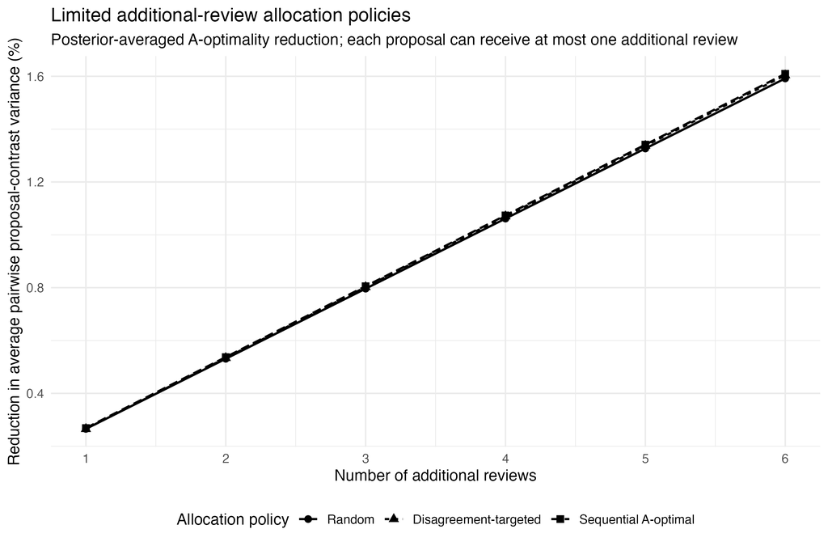

Figure 9: Posterior-averaged reduction in average pairwise proposal-contrast variance under random, disagreement-targeted and sequential A-optimal allocation of up to six additional reviews. Each proposal can receive at most one additional review.

At six reviews, sequential A-optimal allocation exceeded the random benchmark by only 0.017 percentage points. Thus, under V1 and this global uncertainty criterion, optimising the exact placement of a small number of additional reviews provides little improvement over random supplementation in the present CRS design.

This result concerns global A-optimality, not all possible notions of ranking uncertainty. The disagreement-targeted policy deliberately addresses a different substantive objective by concentrating additional opinions on proposals whose original reviewers disagreed.

## 6.8 Generalisation beyond the CRS design

The matrix formulation applies more generally to crossed reviewer–proposal models with an additive Gaussian information structure. The value of particular additional reviews will nevertheless depend on the existing assignment graph, the fitted variance components and the chosen uncertainty criterion.

The sequential A-optimal policy considered here is greedy rather than jointly optimal over a fixed review budget. A more general design framework could instead optimise sets of additional assignments jointly, subject to the relevant operational constraints.

The disagreement-targeted policy also uses the disagreement observed in the original two reviews and does not update this quantity after a hypothetical third grade. A prospective implementation could instead observe each new grade, refit or update the hierarchical model, and use the resulting information when choosing the next assignment.

Any operational implementation would additionally need to restrict candidate assignments according to reviewer expertise, conflicts of interest, workload and availability.

# 7 Discussion and recommendations

## 7.1 Answers to the research questions

**Research Question 1.** Under V1, P022, P032, P023 and P041 occupied the first four posterior-mean positions, with expected ranks from 13.08 to 16.22. Their 90% posterior rank intervals nevertheless extended to ranks 36–38, showing substantial uncertainty in the exact latent ordering.

**Research Question 2.** The four proposals satisfying the CRS qualification rule were also the first four by posterior-mean V1 effect. The Bayesian model therefore did not change the group identified by the final rule, but quantified substantial uncertainty that the coarse observed-score ranking, with many ties, does not show directly.

**Research Question 3.** V1 showed stable MCMC computation, reproduced the observed mean, dispersion and mean reviewer disagreement reasonably well, and showed negligible ranking sensitivity to the alternative scale priors. Its principal model-form limitation is the continuous Gaussian treatment of the integer 1–5 score, which produced about 6.6% of replicated grades outside the admissible range.

**Research Question 4.** Scientific quality was the criterion most strongly associated with the holistic overall grade. Replacing that grade by an equal-weight criterion average changed the Bayesian ordering substantially more than changing from V0 to V1: the expected-rank correlation between the two V1 outcomes was 0.863, and only three of the four original qualifiers remained in the criterion-average posterior-mean top four. This demonstrates sensitivity to outcome definition without establishing that either outcome is preferable.

**Research Question 5.** Under A-optimality, P026–R02, P005–R02 and P015–R02 formed an almost tied highest-value group. A- and D-optimality gave similar candidate rankings ($\rho_{\mathrm S}=0.926$), whereas E-optimality produced a substantially different ordering, showing that the preferred additional review depends on the uncertainty criterion.

As a practical extension, random, disagreement-targeted and sequential A-optimal allocation were compared for up to six additional reviews. Their reductions in the global A-optimality criterion were nearly identical: 1.592%, 1.604% and 1.609%, respectively, at a budget of six reviews.

## 7.2 Interpretation of the main findings

The central result is not a different set of leading proposals produced by the Bayesian model. The final CRS qualifiers also occupy the first four posterior-mean V1 positions, while the posterior distributions show that the exact latent ordering is weakly identified. This is consistent with the fitted variance structure, in which proposal-level variation is small relative to residual review-level variation.

Two different forms of sensitivity should be distinguished. Simplifying the Heyard reference model from V0 to V1 changes the ranking very little, whereas changing the evaluation outcome from the holistic grade to an equal-weight criterion average has a noticeably larger effect. In the analyses considered here, the definition of what is being ranked therefore matters more than the difference between the two hierarchical model specifications.

The review-design analysis links this uncertainty to data collection. Additional assignments can differ in their statistical information value, and the preferred single edge depends on the uncertainty criterion. However, for the global A-optimality objective and budgets of up to six reviews, the exact allocation policy matters very little. This does not rule out larger differences under other assignment structures or more decision-focused objectives.

Taken together, the analyses of this project did not identify a substantially superior ranking model or additional-review allocation policy. Their main contribution is instead to distinguish which conclusions are robust, which depend materially on the definition of the evaluation outcome, and where additional methodological complexity provides little gain under the present sparse design.

## 7.3 Implications for CRS

For future evaluations, the score used for the final decision should be specified clearly before reviews are collected. The 2026 call described an average across criteria and reviewers, whereas the implemented procedure used a separate holistic overall grade. The present analysis shows that these outcome definitions can produce meaningfully different proposal orderings.

When only a few reviews are available, fine distinctions between proposal ranks should also be interpreted cautiously. Posterior rank intervals or selected pairwise posterior probabilities can complement a transparent score-based decision rule by showing how strongly the available reviews support particular comparisons.

Additional review capacity can be treated as an explicit design choice. However, the present global A-optimality comparison gives little reason to adopt a complex allocation algorithm solely to improve average pairwise precision. Other objectives may still justify selective review, for example resolving strong reviewer disagreement or uncertainty near a decision boundary. Any prospective allocation rule would first need to respect reviewer expertise, conflicts of interest, workload and availability.

## 7.4 Ranking uncertainty and decision making

Broad posterior rank intervals do not imply that the four funding decisions were incorrect. The CRS rule is a deterministic qualification threshold based on the observed grades, whereas the Bayesian model quantifies uncertainty in the latent ordering of proposals. The same four qualifiers occupied the first four posterior-mean V1 positions, and funding capacity was not binding. The uncertainty result is therefore narrower: the available reviews do not support strong claims about the exact ordering of many proposals. This distinction would become more consequential if a future decision required a strict ranking near a funding boundary.

## 7.5 Limitations

First, the dataset is small and sparse: 42 proposals were evaluated by nine reviewers, with only two reviews per proposal. Variance components and latent ranks are therefore estimated from limited replication.

Second, reviewer assignment was based on expertise and availability rather than random allocation. Reviewer effects consequently represent reviewer-associated scoring tendencies rather than causal measures of bias. The Chapter 6 candidate set also omits expertise, conflicts, workload and availability constraints.

Third, the review-design calculations update conditional covariance while holding scale parameters fixed within each posterior draw. They do not simulate future grades or refit the complete hierarchy after each additional review. The disagreement-targeted policy likewise uses disagreement from the original two reviews.

Fourth, V1 models the five-point holistic grade using a homogeneous Gaussian likelihood. This permits values outside the observed 1–5 range. The prior-sensitivity analysis does not address this likelihood assumption, and an ordinal model was not fitted as a formal sensitivity analysis.

Fifth, the criterion-average analysis is an equal-weight counterfactual. It does not identify how reviewers combined the criteria when assigning the holistic grade and does not establish that equal weighting is preferable.

Finally, this is a retrospective analysis of one small grant call. The qualitative findings may inform related settings, but the numerical rankings, variance estimates and preferred additional assignments are specific to the CRS data and fitted model.

## 7.6 Future work

A natural model extension is an ordinal hierarchical specification that respects the five observed score categories while retaining proposal and reviewer effects. Comparing such a model with V1 would directly test whether the continuous-score approximation affects the ranking conclusions.

For review design, future work could incorporate operational eligibility constraints such as expertise, conflicts of interest, workload and availability, and compare the present greedy sequential rule with joint optimisation under a fixed review budget. A fully adaptive design could observe each additional grade, refit the Bayesian model and then choose the next assignment. Decision-focused utilities could also target uncertainty for particular proposals, for example those with substantial reviewer disagreement or near a qualification boundary, rather than averaging uncertainty over all proposal pairs. Within such a target subset, future work could compare average-case A-optimal allocation with worst-case E-optimal allocation. The substantially different single-review E-optimal ranking observed here suggests that such a decision-focused comparison could yield different allocation choices from the present global A-optimal analysis.

The limited-budget comparison also raises a broader structural question: when does graph-based targeting meaningfully outperform random supplementation? One hypothesis is that its advantage increases when assignment graphs exhibit strong workload imbalance, clustering or connectivity bottlenecks, particularly when persistent reviewer variation is large relative to residual review-level variation. An edge connecting weakly linked parts of such a graph may then provide substantially more information than an additional review within an already well-connected region. Simulation studies varying both graph structure and variance components could test this hypothesis.

The strongest empirical validation would be prospective: a pre-specified ranking and review-design procedure could be applied in a future CRS call and its predicted information gains compared with the uncertainty observed after additional reviews are collected.

# 8 Conclusion

The CRS Seed Grant 2026 evaluation illustrates the uncertainty that can arise when many proposals are assessed by only a few reviewers. The Bayesian cross-classified model placed the four CRS qualifiers in the first four posterior-mean positions, while showing substantial uncertainty in their exact latent ordering. This conclusion was stable to the Heyard reference specification and to the alternative scale priors tested here. The main model-form limitation remains the continuous Gaussian treatment of the five-point score.

The analysis also showed that the definition of the evaluation outcome matters. Replacing the holistic overall grade with an equal-weight average of the four supporting criteria changed the proposal ordering more noticeably than changing from V0 to V1. This supports specifying clearly in advance which score or summary is intended to drive the decision.

Finally, the reviewer–proposal assignment graph links the review design directly to posterior uncertainty under V1. A-, D- and E-optimality provide principled ways to evaluate hypothetical additional reviews, but for small review budgets the precise allocation strategy had little effect on the global A-optimality criterion in the present CRS design. The broader practical conclusion is therefore to combine transparent decision rules with explicit uncertainty summaries and to define clearly what additional review effort is intended to resolve before choosing an allocation strategy.

# 9 Statement on the use of generative AI

Generative AI tools were used during this project as supporting tools for language editing, brainstorming, code troubleshooting, and discussion of statistical and mathematical concepts.

All model specifications, analyses, code execution, numerical results, figures, interpretations, and final written content were reviewed and verified by the author. Generative AI was not used to make grant-evaluation decisions or to generate the underlying evaluation data.

The confidential key linking pseudonymized proposal and reviewer identifiers to their original identities was not shared with generative AI tools.

Responsibility for the analysis, interpretation, and contents of this report remains with the author.

# References

Bailey, R. A., and Peter J. Cameron. 2011. *Using Graphs to Find the Best Block Designs*. https://arxiv.org/abs/1111.3768.

Cao, Jing, S. Lynne Stokes, and Song Zhang. 2010. “A Bayesian Approach to Ranking and Rater Evaluation: An Application to Grant Reviews.” *Journal of Educational and Behavioral Statistics* 35 (2): 194–214. https://doi.org/10.3102/1076998609353116.

Center for Reproducible Science and Research Synthesis. 2026a. *CRS Seed Grants: Four Projects Approved*. University of Zurich. https://www.crs.uzh.ch/en/news/2026-News/Four-CRS-Seed-Grants-Funded.html.

Center for Reproducible Science and Research Synthesis. 2026b. *CRS Seed Grants: Seed Grants for Research Synthesis and Meta-Research*. University of Zurich. https://www.crs.uzh.ch/en/news/2026-News/CRS-Seed-Grants.html.

Cook, Wade D., Boaz Golany, Moshe Kress, Michal Penn, and Tal Raviv. 2005. “Optimal Allocation of Proposals to Reviewers to Facilitate Effective Ranking.” *Management Science* 51 (4): 655–61. https://doi.org/10.1287/mnsc.1040.0290.

Eblen, Matthew K., Robin M. Wagner, Deepshikha RoyChowdhury, Katherine C. Patel, and Katrina Pearson. 2016. “How Criterion Scores Predict the Overall Impact Score and Funding Outcomes for National Institutes of Health Peer-Reviewed Applications.” *PLOS ONE* 11 (6): e0155060. https://doi.org/10.1371/journal.pone.0155060.

Erosheva, Elena A., Sheridan Grant, Mei-Ching Chen, Mark D. Lindner, Richard K. Nakamura, and Carole J. Lee. 2020. “NIH Peer Review: Criterion Scores Completely Account for Racial Disparities in Overall Impact Scores.” *Science Advances* 6 (23): eaaz4868. https://doi.org/10.1126/sciadv.aaz4868.

Graves, Nicholas, Adrian G. Barnett, and Philip Clarke. 2011. “Funding Grant Proposals for Scientific Research: Retrospective Analysis of Scores by Members of Grant Review Panel.” *BMJ* 343: d4797. https://doi.org/10.1136/bmj.d4797.

Heyard, Rachel, Manuela Ott, Georgia Salanti, and Matthias Egger. 2022. “Rethinking the Funding Line at the Swiss National Science Foundation: Bayesian Ranking and Lottery.” *Statistics and Public Policy* 9 (1): 110–21. https://doi.org/10.1080/2330443X.2022.2086190.

Heyard, Rachel, David G. Pina, Ivan Buljan, and Ana Marušić. 2025. “Assessing the Potential of a Bayesian Ranking as an Alternative to Consensus Meetings for Decision Making in Research Funding: A Case Study of Marie Skłodowska-Curie Actions.” *PLOS ONE* 20 (3): e0317772. https://doi.org/10.1371/journal.pone.0317772.

Jayasinghe, Upali W., Herbert W. Marsh, and Nigel Bond. 2003. “A Multilevel Cross-Classified Modelling Approach to Peer Review of Grant Proposals: The Effects of Assessor and Researcher Attributes on Assessor Ratings.” *Journal of the Royal Statistical Society: Series A (Statistics in Society)* 166 (3): 279–300. https://doi.org/10.1111/1467-985X.00278.

Johnson, Valen E. 2008. “Statistical Analysis of the National Institutes of Health Peer Review System.” *Proceedings of the National Academy of Sciences of the United States of America* 105 (32): 11076–80. https://doi.org/10.1073/pnas.0804538105.

Kaplan, David, Nicola Lacetera, and Celia Kaplan. 2008. “Sample Size and Precision in NIH Peer Review.” *PLOS ONE* 3 (7): e2761. https://doi.org/10.1371/journal.pone.0002761.

Laird, Nan M., and Thomas A. Louis. 1989. “Empirical Bayes Ranking Methods.” *Journal of Educational Statistics* 14 (1): 29–46. https://doi.org/10.3102/10769986014001029.

Osting, Braxton, Christoph Brune, and Stanley J. Osher. 2014. “Optimal Data Collection for Informative Rankings Expose Well-Connected Graphs.” *Journal of Machine Learning Research* 15: 2981–3012.

Simpson, Edwin, and Stephen Roberts. 2015. “Bayesian Methods for Intelligent Task Assignment in Crowdsourcing Systems.” In *Scalable Decision Making: Uncertainty, Imperfection, Deliberation*, edited by Tatiana Guy, Miroslav Kárný, and David Wolpert, vol. 538. Studies in Computational Intelligence. Springer. https://doi.org/10.1007/978-3-319-15144-1_1.

Stelmakh, Ivan, Nihar B. Shah, and Aarti Singh. 2021. “PeerReview4All: Fair and Accurate Reviewer Assignment in Peer Review.” *Journal of Machine Learning Research* 22 (163): 1–66.

Tsagris, Michail, Christina Beneki, and Hossein Hassani. 2014. “On the Folded Normal Distribution.” *Mathematics* 2 (1): 12–28. https://doi.org/10.3390/math2010012.

## 10 Supplementary methods and analyses

## 10.1 Correlation definitions

For criterion $c$, the sample Pearson correlation with the holistic overall grade is

$$\operatorname{Cor}_{\mathrm P}(C_{\cdot c},Y)
=
\frac{
\sum_{r=1}^{n}(C_{rc}-\bar C_c)(Y_r-\bar Y)
}{
\sqrt{
\sum_{r=1}^{n}(C_{rc}-\bar C_c)^2
\sum_{r=1}^{n}(Y_r-\bar Y)^2
}
},$$

where $n=84$, $C_{\cdot c}=(C_{1c},\ldots,C_{nc})^\top$ and $Y=(Y_1,\ldots,Y_n)^\top$. The corresponding sample Spearman correlation is

$$\operatorname{Cor}_{\mathrm S}(C_{\cdot c},Y)
=
\operatorname{Cor}_{\mathrm P}\!\left(R(C_{\cdot c}),R(Y)\right),$$

where $R(\cdot)$ denotes the rank transformation and average ranks are used for ties.

## 10.2 Bayesian updating and partial pooling in V1

This section gives a mathematical explanation of how the observed grades inform the proposal and reviewer effects in V1, making the Bayesian updating mechanism and resulting partial pooling explicit.

### 10.2.1 From the model to the posterior distribution

Recall that V1 represents review $r$ as

$$Y_r
=
\bar Y
+
\theta_{p(r)}
+
b_{a(r)}
+
\varepsilon_r,
\qquad
\varepsilon_r\sim\mathcal{N}(0,\sigma^2),$$

where $\theta_i$ is the latent effect of proposal $i$, $b_j$ is the effect of reviewer $j$, and $\sigma^2$ is the residual review-level variance. The hierarchical distributions are

$$\theta_i\sim\mathcal{N}(0,\tau_\theta^2),
\qquad
b_j\sim\mathcal{N}(0,\tau_b^2).$$

For given values of the model parameters, the density of one observed grade is

$$p(Y_r\mid\theta,b,\sigma)
=
\frac{1}{\sqrt{2\pi\sigma^2}}
\exp\!\left[
-\frac{
\left(
Y_r-\bar Y-\theta_{p(r)}-b_{a(r)}
\right)^2
}{
2\sigma^2
}
\right].$$

Conditional on the model parameters, the review-level residuals are assumed independent. The likelihood of the complete observed dataset $Y=(Y_1,\ldots,Y_{84})^\top$ is therefore

$$p(Y\mid\theta,b,\sigma)
=
\prod_{r=1}^{84}
p(Y_r\mid\theta,b,\sigma).$$

Bayes’ theorem combines this likelihood with the prior distributions. For all unknown quantities together,

$$p(\theta,b,\tau_\theta,\tau_b,\sigma\mid Y)
=
\frac{
p(Y\mid\theta,b,\sigma)\,
p(\theta,b,\tau_\theta,\tau_b,\sigma)
}{
p(Y)
}.$$

Since the denominator $p(Y)$ does not depend on the unknown parameters, the same relationship can be written as

$$p(\theta,b,\tau_\theta,\tau_b,\sigma\mid Y)
\propto
p(Y\mid\theta,b,\sigma)\,
p(\theta,b,\tau_\theta,\tau_b,\sigma),$$

where $\propto$ means “proportional to”. Using the hierarchical structure of V1 gives

$$p(\theta,b,\tau_\theta,\tau_b,\sigma\mid Y)
\propto
p(Y\mid\theta,b,\sigma)
\left[
\prod_{i=1}^{42}p(\theta_i\mid\tau_\theta)
\right]
\left[
\prod_{j=1}^{9}p(b_j\mid\tau_b)
\right]
p(\tau_\theta)p(\tau_b)p(\sigma).$$

The posterior therefore combines the information in the observed grades, through the likelihood, with the hierarchical prior distributions.

### 10.2.2 Updating one proposal effect

The partial-pooling mechanism can be seen explicitly by considering one proposal $i$. Let

$$\mathcal{R}_i
=
\{r:p(r)=i\}$$

denote the set of reviews received by proposal $i$, and define

$$n_i
=
|\mathcal{R}_i|.$$

Thus, $n_i$ is simply the number of reviews received by proposal $i$. In the CRS data,

$$n_i=2$$

for every proposal.

To make the updating calculation transparent, suppose temporarily that the reviewer effects $b$, the residual variance $\sigma^2$, and the between-proposal variance $\tau_\theta^2$ are known.

For a review $r\in\mathcal{R}_i$, define the reviewer-adjusted grade

$$Z_r
=
Y_r-\bar Y-b_{a(r)}.$$

Conditional on the assumed reviewer effects, this removes the reviewer-specific component from the observed grade.

Substituting the V1 model gives

$$Z_r
=
\theta_i+\varepsilon_r,
\qquad
\varepsilon_r\sim\mathcal{N}(0,\sigma^2),$$

and therefore

$$Z_r\mid\theta_i
\sim
\mathcal{N}(\theta_i,\sigma^2).$$

The likelihood for $\theta_i$ based on its $n_i$ adjusted grades is

$$p(Z_i\mid\theta_i,\sigma)
=
\prod_{r\in\mathcal{R}_i}
p(Z_r\mid\theta_i,\sigma),$$

where $Z_i$ denotes the collection of adjusted grades for proposal $i$. Ignoring multiplicative constants that do not depend on $\theta_i$,

$$p(Z_i\mid\theta_i,\sigma)
\propto
\exp\!\left[
-\frac{1}{2\sigma^2}
\sum_{r\in\mathcal{R}_i}
(Z_r-\theta_i)^2
\right].$$

The prior distribution

$$\theta_i\sim\mathcal{N}(0,\tau_\theta^2)$$

has density, again ignoring constants independent of $\theta_i$,

$$p(\theta_i\mid\tau_\theta)
\propto
\exp\!\left(
-\frac{\theta_i^2}{2\tau_\theta^2}
\right).$$

Bayes’ theorem gives

$$p(\theta_i\mid Z_i,\sigma,\tau_\theta)
\propto
p(Z_i\mid\theta_i,\sigma)\,
p(\theta_i\mid\tau_\theta),$$

so

$$p(\theta_i\mid Z_i,\sigma,\tau_\theta)
\propto
\exp\!\left[
-\frac{1}{2\sigma^2}
\sum_{r\in\mathcal{R}_i}
(Z_r-\theta_i)^2
-\frac{\theta_i^2}{2\tau_\theta^2}
\right].$$

To identify this posterior distribution, expand the square:

$$\sum_{r\in\mathcal{R}_i}(Z_r-\theta_i)^2
=
\sum_{r\in\mathcal{R}_i}Z_r^2
-
2\theta_i
\sum_{r\in\mathcal{R}_i}Z_r
+
n_i\theta_i^2.$$

The term $\sum Z_r^2$ does not depend on $\theta_i$ and can therefore be absorbed into the proportionality constant. The remaining terms give

$$p(\theta_i\mid Z_i,\sigma,\tau_\theta)
\propto
\exp\!\left[
-\frac{1}{2}
\left\{
\left(
\frac{n_i}{\sigma^2}
+
\frac{1}{\tau_\theta^2}
\right)\theta_i^2
-
2
\left(
\frac{
\sum_{r\in\mathcal{R}_i}Z_r
}{
\sigma^2
}
\right)\theta_i
\right\}
\right].$$

A normal density with mean $\mu_i^{(\theta)}$ and variance $v_i^{(\theta)}$ has the same quadratic form,

$$\exp\!\left[
-\frac{1}{2v_i^{(\theta)}}
\left(
\theta_i-\mu_i^{(\theta)}
\right)^2
\right].$$

Expanding this square and comparing coefficients gives

$$\frac{1}{v_i^{(\theta)}}
=
\frac{1}{\tau_\theta^2}
+
\frac{n_i}{\sigma^2},$$

and therefore

$$v_i^{(\theta)}
=
\left(
\frac{1}{\tau_\theta^2}
+
\frac{n_i}{\sigma^2}
\right)^{-1}.$$

The coefficient of $\theta_i$ gives

$$\frac{\mu_i^{(\theta)}}{v_i^{(\theta)}}
=
\frac{
\sum_{r\in\mathcal{R}_i}Z_r
}{
\sigma^2
},$$

so

$$\mu_i^{(\theta)}
=
v_i^{(\theta)}
\frac{
\sum_{r\in\mathcal{R}_i}Z_r
}{
\sigma^2
}.$$

Now define the mean reviewer-adjusted grade for proposal $i$ as

$$\bar Z_i
=
\frac{1}{n_i}
\sum_{r\in\mathcal{R}_i}Z_r.$$

Since

$$\sum_{r\in\mathcal{R}_i}Z_r
=
n_i\bar Z_i,$$

the posterior mean simplifies to

$$\mu_i^{(\theta)}
=
\frac{
n_i\tau_\theta^2
}{
\sigma^2+n_i\tau_\theta^2
}
\bar Z_i.$$

Thus,

$$\theta_i\mid Z_i,\sigma,\tau_\theta
\sim
\mathcal{N}
\left(
\mu_i^{(\theta)},
v_i^{(\theta)}
\right).$$

### 10.2.3 Partial pooling

Define the shrinkage factor

$$\kappa_i
=
\frac{
n_i\tau_\theta^2
}{
\sigma^2+n_i\tau_\theta^2
}.$$

Because all variance terms are positive,

$$0<\kappa_i<1.$$

The conditional posterior mean can therefore be written as

$$\mu_i^{(\theta)}
=
\kappa_i\bar Z_i.$$

The reviewer-adjusted observed mean $\bar Z_i$ is consequently pulled toward the prior mean zero rather than being used directly as the estimate of the proposal effect. This is the partial-pooling mechanism.

The amount of pooling is governed by $\kappa_i$. More reviews increase $n_i$ and therefore give the observed grades more influence. Larger residual variation $\sigma^2$ decreases $\kappa_i$ and produces stronger shrinkage, because individual reviews are treated as noisier. Larger between-proposal variation $\tau_\theta^2$ increases $\kappa_i$, allowing proposal effects to remain further away from zero.

For the CRS design, $n_i=2$ for every proposal, so

$$\kappa_i
=
\frac{
2\tau_\theta^2
}{
\sigma^2+2\tau_\theta^2
}.$$

Since $\theta_i=0$ corresponds to a proposal whose expected grade equals the overall mean $\bar Y$, shrinking $\theta_i$ toward zero corresponds to shrinking the proposal’s fitted grade toward the overall evaluation mean.

### 10.2.4 Updating reviewer effects

Reviewer effects are updated in the same way. Let

$$\mathcal{S}_j
=
\{r:a(r)=j\}$$

denote the set of reviews completed by reviewer $j$, and define

$$d_j
=
|\mathcal{S}_j|.$$

Thus, $d_j$ is the number of reviews completed by reviewer $j$.

Suppose temporarily that the proposal effects $\theta$, the residual variance $\sigma^2$, and the between-reviewer variance $\tau_b^2$ are known. Define the proposal-adjusted grade

$$W_r
=
Y_r-\bar Y-\theta_{p(r)}.$$

For reviews completed by reviewer $j$,

$$W_r
=
b_j+\varepsilon_r,$$

so

$$W_r\mid b_j
\sim
\mathcal{N}(b_j,\sigma^2).$$

Combining these observations with the prior

$$b_j\sim\mathcal{N}(0,\tau_b^2)$$

and applying the same normal–normal calculation gives

$$b_j\mid Y,\theta,\sigma,\tau_b
\sim
\mathcal{N}
\left(
\mu_j^{(b)},
v_j^{(b)}
\right),$$

where

$$v_j^{(b)}
=
\left(
\frac{1}{\tau_b^2}
+
\frac{d_j}{\sigma^2}
\right)^{-1}.$$

Define the mean proposal-adjusted grade assigned by reviewer $j$ as

$$\bar W_j
=
\frac{1}{d_j}
\sum_{r\in\mathcal{S}_j}W_r.$$

The conditional posterior mean is then

$$\mu_j^{(b)}
=
\frac{
d_j\tau_b^2
}{
\sigma^2+d_j\tau_b^2
}
\bar W_j.$$

Thus, the several proposals assessed by the same reviewer jointly inform that reviewer’s scoring tendency. Reviewers with more observed reviews are, all else equal, subject to less shrinkage toward zero.

### 10.2.5 From the joint posterior to proposal ranks

The calculations above treat some quantities as known only to make the updating mechanism visible. In the fitted V1 model, the proposal effects, reviewer effects, $\tau_\theta$, $\tau_b$, and $\sigma$ are all unknown and are estimated jointly. Their posterior distributions therefore depend on one another.

JAGS uses Markov chain Monte Carlo to generate draws from this joint posterior. A retained posterior draw $s$ contains

$$\left(
\theta_1^{(s)},\ldots,\theta_{42}^{(s)},
b_1^{(s)},\ldots,b_9^{(s)},
\tau_\theta^{(s)},
\tau_b^{(s)},
\sigma^{(s)}
\right).$$

Each draw represents one set of parameter values compatible with the observed grades and the model assumptions. The proposal effects within that draw,

$$\theta_1^{(s)},\ldots,\theta_{42}^{(s)},$$

are ordered from largest to smallest to obtain one possible proposal ranking. Repeating this calculation across posterior draws produces the posterior rank distributions described in Section 3.5.

The Bayesian ranking therefore follows the sequence

$$\text{observed grades}
\longrightarrow
\text{posterior proposal and reviewer effects}
\longrightarrow
\text{posterior proposal ranks}.$$

Partial pooling enters before the ranking step: the limited and noisy review information is combined with the hierarchical model before the proposal effects are ranked.

## 10.3 V0 reference-model details

Under V0, P022 had posterior-mean rank 1 and expected rank 11.85. P023, P032 and P041 occupied posterior-mean ranks 2, 3 and 4, with expected ranks 15.45, 15.49 and 16.50. Their 90% posterior rank intervals were 1–35, 1–37, 1–37 and 2–38, respectively. The maximum PSRF across monitored V0 parameters was 1.0077 and the minimum effective sample size was 501.

For completeness, Figure 10 shows the comparison between the observed-score rank, posterior-mean rank and expected rank under V0.

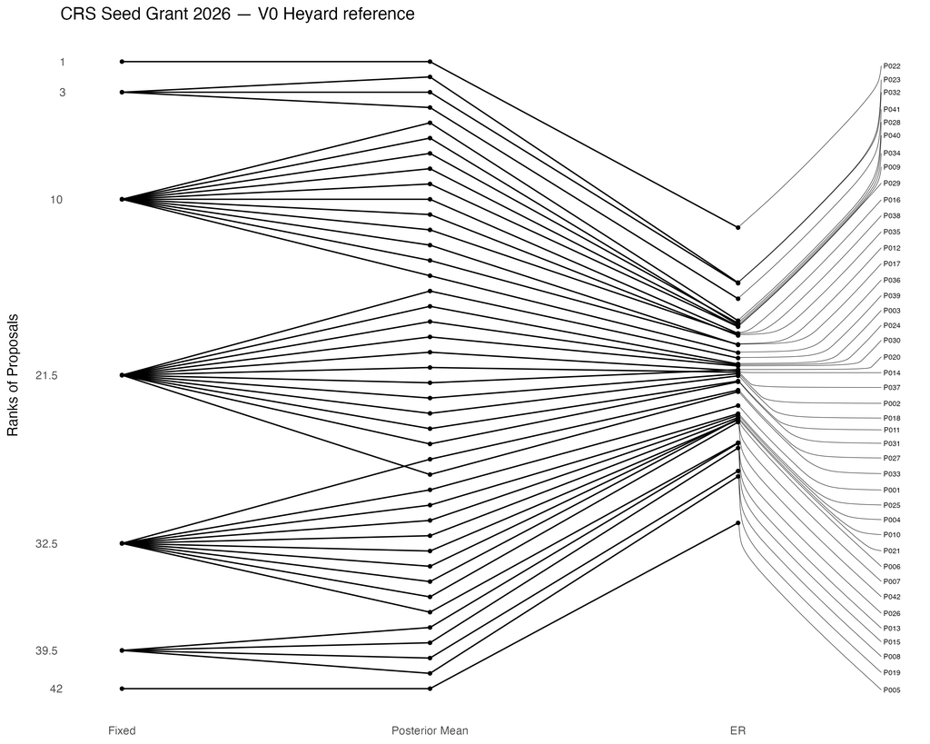

Figure 10: Proposal rankings under the observed-score ranking, posterior-mean ranking and posterior expected rank for the V0 Heyard reference model. The package-generated labels “Fixed” and “ER” correspond to the observed-score rank and posterior expected rank, respectively.

## 10.4 V1 MCMC trace plots

Figure 11 shows the final 5,000 retained iterations from each V1 chain, plotting every fifth value for readability. Numerical diagnostics in the main text are based on the full posterior sample.

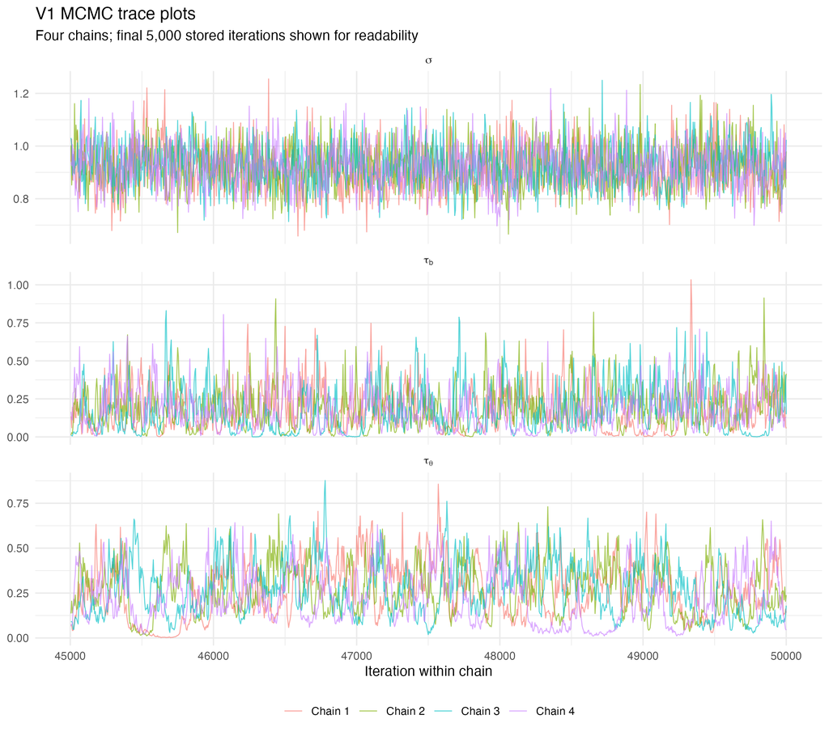

Figure 11: Trace plots for the V1 scale parameters $\tau_\theta$, $\tau_b$, and $\sigma$.

## 10.5 Detailed reviewer-disagreement diagnostic

Consider proposal $i$, reviewed by reviewers $j$ and $k$. Under V1,

$$Y_{ij}-Y_{ik}
=
b_j-b_k+\varepsilon_{ij}-\varepsilon_{ik},$$

so the proposal effect cancels and

$$Y_{ij}-Y_{ik}\mid b_j,b_k,\sigma
\sim
\mathcal{N}(b_j-b_k,2\sigma^2).$$

Taking the absolute value gives a folded normal distribution (Tsagris et al. 2014). If $X\sim\mathcal{N}(\mu,s^2)$, then

$$\operatorname{E}|X|
=
s\sqrt{\frac{2}{\pi}}
\exp\!\left(-\frac{\mu^2}{2s^2}\right)
+
|\mu|
\left[
2\Phi\!\left(\frac{|\mu|}{s}\right)-1
\right],$$

where $\Phi$ is the standard normal cumulative distribution function. In the present setting, $\mu=b_j-b_k$ and $s=\sqrt{2}\sigma$. Evaluating this expression for the observed reviewer pairs and posterior draws gave analytic posterior mean disagreement 1.066, almost identical to the simulated posterior predictive mean 1.064. The posterior predictive probability of mean disagreement at least as large as the observed value 1.095 was 0.401.

Most of the model-implied disagreement is associated with residual review-level variation. If the two reviewer effects are equal, the expected absolute disagreement simplifies to

$$\operatorname{E}|Y_{ij}-Y_{ik}|
=
\frac{2\sigma}{\sqrt{\pi}},$$

which averaged 1.043 over the posterior. Allowing the fitted reviewer effects to differ increased the expected mean disagreement by only about 0.023 on average.

A threshold-based check gave a less favourable result. Observed absolute disagreement was 0 for 10 proposals, 1 for 19 proposals, 2 for 12 proposals and 3 for one proposal. Thus, 13 of 42 proposals had disagreement of at least two score points, giving

$$T_{\mathrm{obs}}
=
\frac{13}{42}
\approx0.310.$$

Let $T_{\mathrm{cont}}^{\mathrm{rep}}$ denote the corresponding proportion calculated from a continuous Gaussian replicated dataset. Its posterior predictive mean was 0.134, and

$$\mathbb{P}
\left(
T_{\mathrm{cont}}^{\mathrm{rep}}
\ge
T_{\mathrm{obs}}
\mid Y
\right)
=
0.0088.$$

Because the observed scores are integer-valued, each replicated grade was also mapped diagnostically to the 1–5 grid,

$$\widetilde Y_r^{\mathrm{rep}}
=
\min\left\{
5,
\max\left\{
1,
\operatorname{round}(Y_r^{\mathrm{rep}})
\right\}
\right\}.$$

Let $T_{\mathrm{disc}}^{\mathrm{rep}}$ denote the proportion of proposals with disagreement of at least two points after this transformation. Its posterior predictive mean increased to 0.255, and

$$\mathbb{P}
\left(
T_{\mathrm{disc}}^{\mathrm{rep}}
\ge
T_{\mathrm{obs}}
\mid Y
\right)
=
0.272.$$

The same transformation did not improve agreement for mean absolute disagreement. Let $D_{\mathrm{obs}}=1.095$ denote the observed mean absolute disagreement and let $D_{\mathrm{disc}}^{\mathrm{rep}}$ denote the corresponding statistic calculated from a grid-mapped replicated dataset. Its posterior predictive mean was 1.020, compared with 1.064 under continuous Gaussian replication. The 95% posterior predictive interval for $D_{\mathrm{disc}}^{\mathrm{rep}}$ was approximately $[0.738,1.333]$, and

$$\mathbb{P}
\left(
D_{\mathrm{disc}}^{\mathrm{rep}}
\ge
D_{\mathrm{obs}}
\mid Y
\right)
=
0.332.$$

Thus, the grid transformation primarily resolves the apparent discrepancy in the threshold-based disagreement statistic rather than the already small difference in mean absolute disagreement.

The broader disagreement pattern is summarised in Figure 12. The observed mean, median, 90th percentile, maximum and proportion of disagreements of at least three score points are all compatible with their posterior predictive distributions. The clearest departure is the frequency of disagreements of at least two score points, which is higher in the observed data than in most continuous replicated datasets. As shown above, this discrepancy is substantially reduced once replicated grades are placed on the same integer-valued 1–5 scale as the observations.

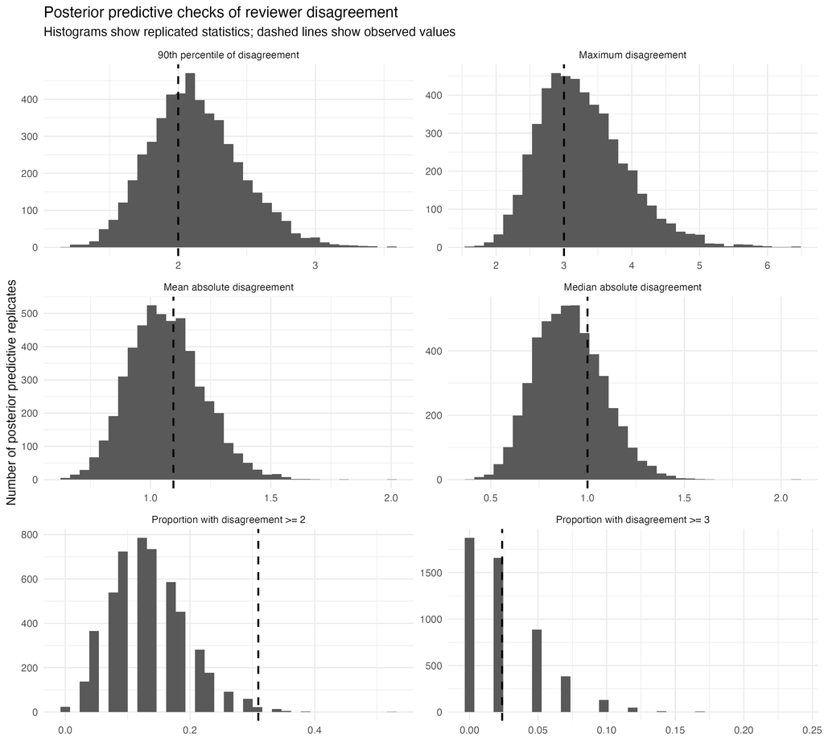

Figure 12: Posterior predictive checks for several summaries of reviewer disagreement under V1. Histograms show statistics from replicated datasets and dashed vertical lines show the corresponding observed values.

## 10.6 Additional posterior predictive summaries

Table 4: Additional posterior predictive summaries for V1 based on 5,000 replicated datasets.

| Statistic | Observed | Replicated mean | 2.5% | 97.5% |
| --- | --- | --- | --- | --- |
| Mean overall grade | 3.476 | 3.474 | 3.241 | 3.704 |
| Standard deviation | 0.950 | 0.975 | 0.781 | 1.201 |
| Mean absolute disagreement | 1.095 | 1.064 | 0.790 | 1.386 |
| Proportion outside 1–5 | 0.000 | 0.066 | 0.012 | 0.143 |

The interval limits are the 2.5th and 97.5th percentiles of each statistic across the 5,000 posterior predictive datasets.

## 10.7 Prior-sensitivity details

Under the $\operatorname{HalfNormal}(0,1)$ scale priors, the posterior medians of $\tau_\theta$, $\tau_b$ and $\sigma$ were 0.209, 0.154 and 0.916, compared with 0.220, 0.157 and 0.920 under the baseline specification. The maximum PSRF was 1.0011 and the minimum effective sample size was 1,306.

Posterior median variance shares were also very similar: the proposal share changed from 0.050 to 0.046, the reviewer share from 0.026 to 0.025 and the residual share from 0.896 to 0.902.

The Spearman correlation between posterior-mean ranks under the two prior specifications was 0.9990. Six proposals changed integer posterior-mean rank, but the changes were small: the mean absolute change was 0.19 positions and the maximum was two positions. The mean widths of the 90% posterior rank intervals were 36.74 and 36.83 under the baseline and half-normal specifications, respectively.

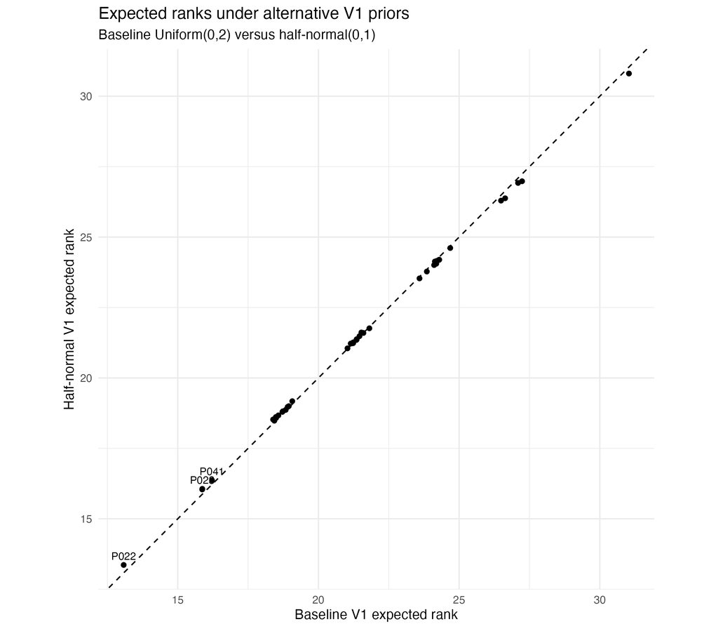

Figure 13: Posterior expected ranks under the baseline V1 prior specification and the half-normal prior-sensitivity specification. The dashed identity line represents identical expected ranks under both models.

## 10.8 Graph representation and conditional posterior precision

This section derives the connection between the reviewer–proposal assignment graph and conditional posterior uncertainty in V1. The construction follows the incidence-graph and graph-Laplacian representation used in incomplete block-design theory (Bailey and Cameron 2011).

Recall that V1 is

$$Y_r
=
\bar Y
+
\theta_{p(r)}
+
b_{a(r)}
+
\varepsilon_r,
\qquad
\varepsilon_r\sim\mathcal N(0,\sigma^2).$$

To obtain the usual signed incidence-matrix representation, define

$$c_j=-b_j.$$

The model can then be written as

$$Y_r-\bar Y
=
\theta_{p(r)}
-
c_{a(r)}
+
\varepsilon_r.$$

Collect the 42 proposal effects and nine transformed reviewer effects into the 51-dimensional vector

$$\beta
=
(\theta_1,\ldots,\theta_{42},
c_1,\ldots,c_9)^\top.$$

For every observed review $r$, corresponding to an edge between proposal $p(r)$ and reviewer $a(r)$, define a row vector $x_r^\top\in\mathbb R^{51}$ with $+1$ in the position corresponding to proposal $p(r)$, $-1$ in the position corresponding to reviewer $a(r)$, and zero elsewhere. Stacking the 84 row vectors gives the oriented incidence matrix

$$X
=
\begin{pmatrix}
x_1^\top\\
\vdots\\
x_{84}^\top
\end{pmatrix},$$

which has dimension $84\times51$.

Let

$$Y
=
(Y_1,\ldots,Y_{84})^\top$$

denote the vector of observed grades and let $\mathbf 1\in\mathbb R^{84}$ denote the vector of ones. Define the centred response vector

$$y
=
Y-\bar Y\mathbf 1.$$

The complete V1 model can then be written in matrix form as

$$y=X\beta+\varepsilon,$$

where

$$\varepsilon\sim
\mathcal N(0,\sigma^2 I_{84}).$$

Conditional on $\sigma$, the likelihood for $\beta$ is therefore

$$p(y\mid\beta,\sigma)
\propto
\exp\left[
-\frac{1}{2\sigma^2}
(y-X\beta)^\top(y-X\beta)
\right].$$

Expanding the quadratic term gives

$$(y-X\beta)^\top(y-X\beta)
=
y^\top y
-
2\beta^\top X^\top y
+
\beta^\top X^\top X\beta.$$

Since $y^\top y$ does not depend on $\beta$, the part of the likelihood involving $\beta$ is

$$p(y\mid\beta,\sigma)
\propto
\exp\left[
-\frac12
\left\{
\beta^\top
\left(
\frac{1}{\sigma^2}X^\top X
\right)
\beta
-
2\beta^\top
\left(
\frac{1}{\sigma^2}X^\top y
\right)
\right\}
\right].$$

Thus, the likelihood contributes the information term

$$\frac{1}{\sigma^2}X^\top X$$

to the posterior precision of $\beta$.

Because $X$ is the oriented incidence matrix of the bipartite reviewer–proposal graph,

$$X^\top X=L_G,$$

where $L_G$ denotes the graph Laplacian. In the usual graph-theoretic definition,

$$L_G=D-A,$$

where $D$ is the diagonal matrix of vertex degrees and $A$ is the adjacency matrix of the graph, i.e. $A_{ij}=1$ if vertices $i$ and $j$ are connected by an edge and $A_{ij}=0$ otherwise. For the present simple bipartite graph, the diagonal entries of $L_G$ are therefore the vertex degrees, while an off-diagonal entry is $-1$ when the corresponding proposal and reviewer are connected by an observed review and zero otherwise.

The identity $X^\top X=L_G$ shows that this standard graph Laplacian arises directly from the incidence-matrix representation of the reviewer–proposal assignments. The orientation chosen for the edges does not affect this product.

The hierarchical priors in V1 are

$$\theta_i\sim\mathcal N(0,\tau_\theta^2),
\qquad
c_j\sim\mathcal N(0,\tau_b^2),$$

where the second relation follows from $c_j=-b_j$ and the symmetric prior on $b_j$. Conditional on $\tau_\theta$ and $\tau_b$, the prior for $\beta$ is therefore multivariate normal with zero mean and precision matrix

$$P_0
=
\operatorname{diag}
\left(
\tau_\theta^{-2}I_{42},
\tau_b^{-2}I_9
\right).$$

Hence

$$p(\beta\mid\tau_\theta,\tau_b)
\propto
\exp\left(
-\frac12\beta^\top P_0\beta
\right).$$

By Bayes’ theorem, conditional on $\sigma$, $\tau_\theta$ and $\tau_b$, the posterior density of $\beta$ is proportional to the product of the likelihood and the prior,

$$p(\beta \mid y,\sigma,\tau_\theta,\tau_b)
\propto
p(y\mid\beta,\sigma)\,
p(\beta\mid\tau_\theta,\tau_b).$$

Because both terms have Gaussian kernels, multiplying them adds their exponents. The quadratic contribution from the likelihood is therefore added to the quadratic contribution from the prior.

Combining likelihood and prior gives

$$p(\beta\mid y,\sigma,\tau_\theta,\tau_b)
\propto
\exp\left[
-\frac12
\left\{
\beta^\top
\left(
P_0+\frac{1}{\sigma^2}X^\top X
\right)
\beta
-
2\beta^\top
\frac{X^\top y}{\sigma^2}
\right\}
\right].$$

A multivariate normal density in $\beta$ has a quadratic kernel of the form

$$\exp\left[
-\frac12
\left\{
\beta^\top Q\beta
-
2\beta^\top h
\right\}
\right].$$

Comparing this form with the posterior kernel above shows that the conditional posterior precision matrix is

$$Q
=
P_0+\frac{1}{\sigma^2}X^\top X
=
P_0+\frac{1}{\sigma^2}L_G.$$

and its conditional posterior covariance matrix is

$$V
=
Q^{-1}
=
\left(
P_0+\frac{1}{\sigma^2}L_G
\right)^{-1}.$$

For completeness, the corresponding conditional posterior mean is

$$m
=
V\frac{X^\top y}{\sigma^2},$$

so that

$$\beta
\mid
y,\sigma,\tau_\theta,\tau_b
\sim
\mathcal N(m,V).$$

Thus, conditional on the variance parameters, the graph Laplacian enters directly into the posterior precision of the proposal and reviewer effects. Adding or removing an edge changes $L_G$ and therefore the conditional posterior covariance $V$.

If a hypothetical additional review is added between proposal $i$ and reviewer $j$, its incidence vector $x_e^\top$ is appended as one additional row of the incidence matrix,

$$X_{\mathrm{new}}
=
\begin{pmatrix}
X\\
x_e^\top
\end{pmatrix}.$$

Therefore,

$$X_{\mathrm{new}}^\top X_{\mathrm{new}}
=
X^\top X + x_e x_e^\top.$$

Since $X^\top X=L_G$, the Laplacian of the augmented graph is

$$L_{G+e}=L_G+x_e x_e^\top.$$

Thus, adding one review contributes the rank-one matrix $x_e x_e^\top$ to the graph Laplacian and consequently changes the conditional posterior precision and covariance.

The derivation conditions on $\sigma$, $\tau_\theta$ and $\tau_b$ to make this relationship explicit. In the fitted Bayesian model these parameters are unknown and estimated jointly by MCMC, as described in Section 3.6 and Section 10.2.

## 10.9 Posterior-median sensitivity of the review-design calculation

As a sensitivity analysis, the single-review design calculation was repeated using posterior-median plug-in values for the V1 scale parameters rather than averaging utility over posterior draws. The posterior medians were

$$\widetilde{\tau}_\theta = 0.220,
\qquad
\widetilde{\tau}_b = 0.157,
\qquad
\widetilde{\sigma} = 0.920.$$

For these fixed values, the conditional covariance matrix was constructed once, and the A-, D- and E-optimality reductions were recalculated for all 294 currently unobserved reviewer–proposal assignments.

Table 5: Agreement between posterior-median plug-in and posterior-averaged candidate rankings.

| Criterion | Spearman correlation with posterior-averaged ranking |
| --- | --- |
| A-optimality | 0.873 |
| D-optimality | 0.990 |
| E-optimality | 0.894 |

The candidate rankings were therefore broadly stable to replacing posterior averaging over the scale parameters by posterior-median plug-in values. D-optimality showed the strongest overall agreement, followed by E-optimality and A-optimality. The leading A-optimal assignments were nevertheless retained under both approaches.

The lower overall rank correlation for A-optimality indicates that candidate positions further down the ranking are more sensitive to whether posterior uncertainty in the scale parameters is averaged over or replaced by a single representative value.

The sensitivity calculation does not compare the magnitudes of the posterior-averaged and plug-in utility reductions directly. Because the design criteria are nonlinear functions of the scale parameters, evaluating them at posterior-median parameter values need not reproduce their posterior means. The comparison is therefore used only to assess robustness of the candidate ordering.